# Regions and the South analysis (puma-level)

Author

Natalie Novoseltseva

# 1 About this qmd

This qmd includes 2 parts:

1. **Regions.** Maps of the outcomes and exposure with the four Census regions marked, and the main models (OLS M3 and SEM) run separately in each region (Northeast, Midwest, South, West), all in one table.
2. **The South.** descriptives and maps, unadjusted groupcomparisons, staged OLS models, and spatial error models (SEM andSDEM) with model checks.

Data: it reads the same two files as the national notebook:

- `data/final/national_puma_dataset_2022_2024.gpkg` from `processing_national_pumas_2022_2024.qmd`: outcomes, controls and PUMA boundaries
- `data/final/puma_prison_exposure.csv` from processing_prison_exposure.qmd`: the prison exposure measures

Outcomes: `overdose_rate_2022_2024` (overdose deaths per 100,000, pooled 2022–2024 CDC tract data) and `pct_divorced_past_yr` (% of ever-married people who divorced in the past year, pooled 2022–2024 ACS).

Exposure: distance-decay exposure to open state and federal prisons (h = 1, 5, 10 and 25 km), plus the number of prisons inside the PUMA and any prison inside the PUMA. The South is defined as the Census South region (16 states and DC).

# 2 Setup

```r
library(tidyverse)
library(sf)
library(gt)
library(broom)
library(fixest)
library(spdep)
library(spatialreg)
library(tigris)
library(patchwork)

options(tigris_use_cache = TRUE)
set.seed(2024)
```

## 2.1 Data

```r
# Exposure measures from processing_prison_exposure.qmd, outcomes and controls (with boundaries)
# from processing_national_pumas_2022_2024.qmd
exposure <- read_csv("data/final/puma_prison_exposure.csv",
                     col_types = cols(GEOID20 = col_character()))

# Census region for each state (base R state lists; DC added by hand)
state_regions <- tibble(state  = c(state.abb, "DC"),
                        region = c(as.character(state.region), "South")) %>%
  mutate(region = recode(region, "North Central" = "Midwest")) %>%
  left_join(distinct(tidycensus::fips_codes, state, state_code), by = "state") %>%
  select(state_fips = state_code, region)

puma_geo <- st_read("data/final/national_puma_dataset_2022_2024.gpkg", quiet = TRUE) %>%
  select(-any_of(setdiff(names(exposure), "GEOID20"))) %>%   # avoid .x/.y if the gpkg already has exposure columns
  left_join(exposure, by = "GEOID20") %>%
  left_join(state_regions, by = "state_fips") %>%
  mutate(rural = pct_pop_nonmetro > 50)                      # rural = more than half the population in non-metro tracts

puma_df <- puma_geo %>% st_drop_geometry()

nrow(puma_df)            # 2462
```

```
[1] 2462
```

```r
count(puma_df, region)   # PUMAs per region
```

```
     region   n
1   Midwest 506
2 Northeast 423
3     South 952
4      West 581
```

```r
count(puma_df, rural)    # rural vs. not
```

```
  rural    n
1 FALSE 2061
2  TRUE  401
```

```r
# Subsets: with boundaries (for maps and spatial models) and as plain tables
south_puma_geo       <- puma_geo %>% filter(region == "South")
south_rural_puma_geo <- puma_geo %>% filter(region == "South", rural)

south_puma_df       <- south_puma_geo       %>% st_drop_geometry()
south_rural_puma_df <- south_rural_puma_geo %>% st_drop_geometry()

tibble(sample = c("National", "South", "South rural"),
       PUMAs  = c(nrow(puma_df),
                  nrow(south_puma_df), nrow(south_rural_puma_df)))
```

```
# A tibble: 3 × 2
  sample      PUMAs
  <chr>       <int>
1 National     2462
2 South         952
3 South rural   163
```

```r
# Outcomes and their labels, used throughout
outcomes <- c(
  overdose_rate_2022_2024 = "Overdose deaths per 100,000",
  pct_divorced_past_yr    = "% of ever-married divorced in past year"
)

# Lower 48 for maps (Alaska and Hawaii would stretch the map); projected for correct shapes
puma_geo_l48 <- puma_geo %>%
  filter(!state_fips %in% c("02", "15")) %>%
  st_transform(5070)

# Open state and federal prisons, for plotting on the maps
prisons <- st_read("data/raw/prison-boundaries-1-geojson.geojson", quiet = TRUE) %>%
  st_make_valid() %>%
  filter(STATUS == "OPEN", TYPE %in% c("STATE", "FEDERAL")) %>%
  st_centroid() %>%
  st_transform(5070) %>%
  st_filter(st_union(puma_geo_l48))
```

## 2.2 Model setup (shared by both parts)

Exposure measures, controls and model specifications, the same as in the national notebook.

```r
# Census division for each state (base R state lists; DC added by hand)
state_lookup <- tibble(state = state.abb,
                       division = as.character(state.division)) %>%
  add_row(state = "DC", division = "South Atlantic") %>%
  left_join(distinct(tidycensus::fips_codes, state, state_code), by = "state") %>%
  select(state_fips = state_code, division)

# Exposure measures: variable -> label
exposures <- c(
  prison_exp_h1          = "Exposure, h = 1 km",
  prison_exp_h5          = "Exposure, h = 5 km",
  prison_exp_h10         = "Exposure, h = 10 km",
  prison_exp_h25         = "Exposure, h = 25 km",
  num_prisons_in_puma    = "Number of prisons in PUMA",
  prison_present_in_puma = "Prison in PUMA (0/1)"
)

# Control groups
ctrl_geo  <- c("log_pop_density", "pct_pop_nonmetro", "log_pop")
ctrl_econ <- c("pct_unemployed", "log_medhhinc")
ctrl_educ <- c("pct_bachelors_plus")
ctrl_race <- c("pct_nonwhite")
ctrl_religion <-c("pct_religious")
ctrl_all  <- c(ctrl_geo, ctrl_econ, ctrl_educ, ctrl_race)
ctrl_all_div  <- c(ctrl_geo, ctrl_econ, ctrl_educ, ctrl_race, ctrl_religion)

# Model specifications: one row per stage, with its controls and fixed effects
specs_od <- tibble(
  spec     = c("M1", "M2", "M3a", "M3b", "M3c", "M3d", "M3", "M3-div"),
  controls = list(character(0), ctrl_geo, c(ctrl_geo, ctrl_econ), c(ctrl_geo, ctrl_educ),
                  c(ctrl_geo, ctrl_race), ctrl_all, ctrl_all, ctrl_all),
  fe       = c(NA, NA, NA, NA, NA, NA, "state_fips", "division")
)

specs_div <- tibble(
  spec     = c("M1", "M2", "M3a", "M3b", "M3c", "M3d", "M3", "M3-div"),
  controls = list(character(0), ctrl_geo, c(ctrl_geo, ctrl_econ), c(ctrl_geo, ctrl_educ),
                  c(ctrl_geo, ctrl_race), ctrl_all_div, ctrl_all_div, ctrl_all_div),
  fe       = c(NA, NA, NA, NA, NA, NA, "state_fips", "division")
)

# Both together, with the outcome each set of specs belongs to
specs <- bind_rows(
  specs_od  %>% mutate(y = "overdose_rate_2022_2024"),
  specs_div %>% mutate(y = "pct_divorced_past_yr")
)

weight_labels <- c(queen = "Queen", knn = "kNN (k = 6)")

# National model data: division added; continuous exposures standardized with the
# national mean and SD (used for the regional comparison)
puma_m <- puma_df %>%
  left_join(state_lookup, by = "state_fips") %>%
  mutate(across(all_of(setdiff(names(exposures), "prison_present_in_puma")),
                ~ (.x - mean(.x, na.rm = TRUE)) / sd(.x, na.rm = TRUE)))
```

# 3 REGIONS

## 3.1 Maps

```r
# Census region outlines: state boundaries dissolved by region
region_map <- tigris::states(cb = TRUE, year = 2020, progress_bar = FALSE) %>%
  filter(STATEFP %in% unique(puma_geo_l48$state_fips)) %>%
  left_join(state_regions, by = c("STATEFP" = "state_fips")) %>%
  st_transform(st_crs(puma_geo_l48)) %>%
  group_by(region) %>%
  summarise()

# Pieces shared by the maps; add them with "+"
map_theme    <- list(theme_void(), theme(plot.title = element_text(face = "bold")))
region_layer <- geom_sf(data = region_map, fill = NA, colour = "black", linewidth = 0.4)
```

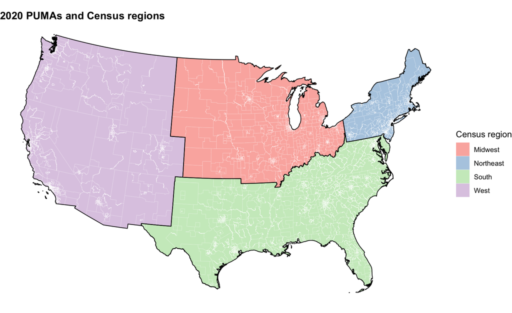

```r
ggplot(puma_geo_l48) +
  geom_sf(aes(fill = region), colour = "white", linewidth = 0.05) +
  region_layer +
  scale_fill_brewer(palette = "Pastel1", name = "Census region") +
  labs(title = "2020 PUMAs and Census regions") +
  map_theme
```

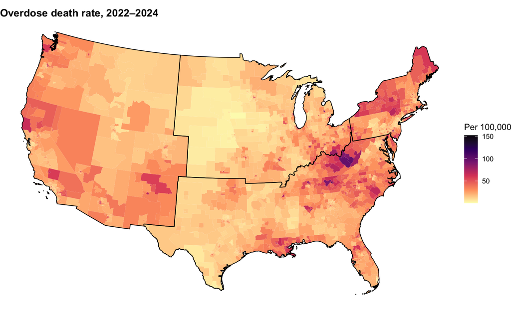

```r
ggplot(puma_geo_l48) +
  geom_sf(aes(fill = overdose_rate_2022_2024), colour = NA) +
  scale_fill_viridis_c(name = "Per 100,000", option = "magma", direction = -1,
                       na.value = "grey85") +
  region_layer +
  labs(title = "Overdose death rate, 2022–2024") +
  map_theme
```

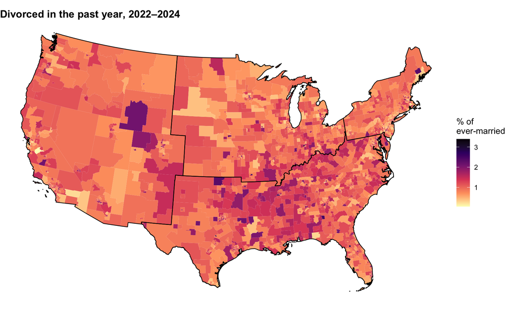

```r
ggplot(puma_geo_l48) +
  geom_sf(aes(fill = pct_divorced_past_yr), colour = NA) +
  scale_fill_viridis_c(name = "% of\never-married", option = "magma", direction = -1,
                       na.value = "grey85") +
  region_layer +
  labs(title = "Divorced in the past year, 2022–2024") +
  map_theme
```

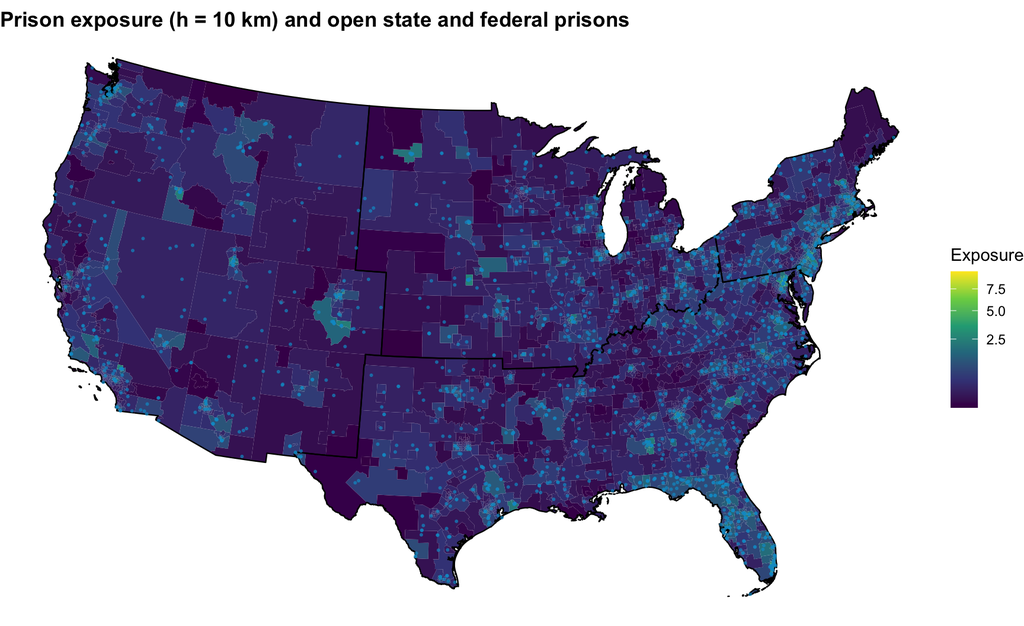

```r
ggplot(puma_geo_l48) +
  geom_sf(aes(fill = prison_exp_h10), colour = NA) +
  scale_fill_viridis_c(name = "Exposure", option = "viridis", trans = "sqrt",
                       na.value = "grey85") +
  region_layer +
  geom_sf(data = prisons, size = 0.4, colour = "deepskyblue3", alpha = 0.6) +
  labs(title = "Prison exposure (h = 10 km) and open state and federal prisons") +
  map_theme
```

## 3.2 Outcomes and exposure by region

```r
puma_df %>%
  group_by(region) %>%
  summarise(PUMAs              = n(),
            overdose_mean      = mean(overdose_rate_2022_2024, na.rm = TRUE),
            divorce_mean       = mean(pct_divorced_past_yr, na.rm = TRUE),
            exposure_h10_mean  = mean(prison_exp_h10, na.rm = TRUE),
            pct_with_prison    = 100 * mean(prison_present_in_puma, na.rm = TRUE),
            pct_nonmetro_pumas = 100 * mean(rural, na.rm = TRUE)) %>%
  gt() %>%
  fmt_number(columns = c(overdose_mean, divorce_mean, exposure_h10_mean), decimals = 2) %>%
  fmt_number(columns = c(pct_with_prison, pct_nonmetro_pumas), decimals = 1) %>%
  cols_label(region = "Region", overdose_mean = "Overdose (mean)", divorce_mean = "Divorce (mean)",
             exposure_h10_mean = "Exposure h = 10 km (mean)",
             pct_with_prison = "% PUMAs with a prison", pct_nonmetro_pumas = "% non-metro PUMAs") %>%
  tab_header(title = "Outcomes and exposure by Census region")
```

Outcomes and exposure by Census region

| Region | PUMAs | Overdose (mean) | Divorce (mean) | Exposure h = 10 km (mean) | % PUMAs with a prison | % non-metro PUMAs |
| --- | --- | --- | --- | --- | --- | --- |
| Midwest | 506 | 25.56 | 1.01 | 0.59 | 39.5 | 24.7 |
| Northeast | 423 | 30.29 | 0.96 | 1.16 | 27.4 | 11.3 |
| South | 952 | 28.11 | 1.14 | 0.81 | 40.0 | 17.1 |
| West | 581 | 26.20 | 1.04 | 0.64 | 29.6 | 11.2 |

## 3.3 Models by region

The M3 specification (all controls + state fixed effects) run separately in each region, for every outcome and exposure: OLS with state-clustered SEs, and SEM with queen weights built within the region. Exposures are standardized nationally, so the β’s can be compared across regions.

```r
# One sample per region and outcome: complete cases for that outcome's M3 controls,
# with boundaries, queen weights and eigenvalues built within the region
region_data <- expand_grid(region = c("Northeast", "Midwest", "South", "West"),
                           y      = names(outcomes)) %>%
  left_join(specs %>% filter(spec == "M3") %>% select(y, controls), by = "y") %>%
  mutate(
    data = pmap(list(region, y, controls),
                ~ puma_m %>%
                    filter(region == ..1) %>%
                    drop_na(all_of(c(..2, names(exposures), ..3, "state_fips")))),
    # Same PUMAs with boundaries; the spatial models use this table so the rows match the weights
    geo  = map(data, ~ puma_geo %>%
                         select(GEOID20) %>%
                         st_transform(5070) %>%
                         inner_join(.x, by = "GEOID20")),
    lw   = map(geo, ~ nb2listw(poly2nb(.x, queen = TRUE, snap = 1), style = "W", zero.policy = TRUE)),
    eig  = map(lw, ~ eigenw(similar.listw(.x))),
    n    = map_int(data, nrow)
  )
region_data %>% select(region, y, n)   # PUMAs per region and outcome
```

```
# A tibble: 8 × 3
  region    y                           n
  <chr>     <chr>                   <int>
1 Northeast overdose_rate_2022_2024   423
2 Northeast pct_divorced_past_yr      423
3 Midwest   overdose_rate_2022_2024   506
4 Midwest   pct_divorced_past_yr      506
5 South     overdose_rate_2022_2024   952
6 South     pct_divorced_past_yr      952
7 West      overdose_rate_2022_2024   581
8 West      pct_divorced_past_yr      581
```

```r
# Every region x outcome x exposure, with its M3 formula
region_models <- region_data %>%
  expand_grid(x = names(exposures)) %>%
  mutate(rhs         = map2_chr(x, controls, ~ str_c(c(.x, .y), collapse = " + ")),
         formula_ols = str_c(y, " ~ ", rhs, " | state_fips"),
         formula_sem = str_c(y, " ~ ", rhs, " + factor(state_fips)"))

# OLS M3 by region (fast, fitted every time)
region_ols <- region_models %>%
  mutate(model = map2(formula_ols, data, ~ feols(as.formula(.x), data = .y, cluster = ~state_fips)),
         coef  = map2(model, x, ~ tidy(.x) %>%
                                   filter(term == .y) %>%
                                   select(ols_beta = estimate, ols_p = p.value))) %>%
  select(region, y, x, coef) %>%
  unnest(coef)
```

```r
# Run by hand once (4 regions x 2 outcomes x 6 exposures = 48 SEMs); saved and read below
region_models %>%
  mutate(sem = pmap(list(formula_sem, geo, lw, eig),
                    ~ errorsarlm(as.formula(..1), data = st_drop_geometry(..2),
                                 listw = ..3, method = "eigen",
                                 control = list(pre_eig = ..4), zero.policy = TRUE),
                    .progress = "SEM by region")) %>%
  select(region, y, x, sem) %>%
  saveRDS("data/final/region_sem_models.rds")
```

```r
region_sem <- readRDS("data/final/region_sem_models.rds") %>%
  mutate(coef   = map2(sem, x, ~ as_tibble(summary(.x)$Coef, rownames = "term") %>%
                                  filter(term == .y) %>%
                                  transmute(sem_beta = Estimate, sem_p = `Pr(>|z|)`)),
         lambda = map_dbl(sem, ~ .x$lambda)) %>%
  select(region, y, x, coef, lambda) %>%
  unnest(coef)

region_results <- region_ols %>%
  left_join(region_sem, by = c("region", "y", "x")) %>%
  left_join(region_data %>% select(region, y, n), by = c("region", "y")) %>%
  mutate(outcome  = outcomes[y],
         exposure = factor(exposures[x], levels = exposures),
         region   = factor(region, levels = c("Northeast", "Midwest", "South", "West")))

region_results %>%
  select(outcome, exposure, region, n, ols_beta, ols_p, sem_beta, sem_p, lambda) %>%
  arrange(outcome, exposure, region) %>%
  gt(groupname_col = c("outcome", "exposure")) %>%
  fmt_number(columns = c(ols_beta, sem_beta, lambda), decimals = 3) %>%
  fmt_number(columns = c(ols_p, sem_p), decimals = 4) %>%
  cols_label(region = "Region", ols_beta = "OLS β", ols_p = "p",
             sem_beta = "SEM β", sem_p = "p", lambda = "λ") %>%
  tab_spanner(label = "OLS M3 (state-clustered SEs)", columns = c(ols_beta, ols_p)) %>%
  tab_spanner(label = "SEM (queen)", columns = c(sem_beta, sem_p, lambda)) %>%
  tab_style(style = cell_fill(color = "#fff3cd"), locations = cells_body(rows = sem_p < 0.05)) %>%
  tab_header(title = "Exposure coefficients by Census region (M3 specification)",
             subtitle = "Continuous exposures per national SD; presence = with vs. without. Shaded: SEM p < 0.05")
```

Exposure coefficients by Census region (M3 specification)

Continuous exposures per national SD; presence = with vs. without. Shaded: SEM p < 0.05

| Region | n | OLS M3 (state-clustered SEs) OLS β | OLS M3 (state-clustered SEs) p | SEM (queen) SEM β | SEM (queen) p | SEM (queen) λ |
| --- | --- | --- | --- | --- | --- | --- |
| % of ever-married divorced in past year - Exposure, h = 1 km |  |  |  |  |  |  |
| Northeast | 423 | 0.053 | 0.0197 | 0.054 | 0.0001 | −0.136 |
| Midwest | 506 | 0.026 | 0.5459 | 0.029 | 0.2898 | 0.191 |
| South | 952 | 0.026 | 0.0001 | 0.024 | 0.0467 | 0.104 |
| West | 581 | 0.047 | 0.0002 | 0.046 | 0.0208 | 0.074 |
| % of ever-married divorced in past year - Exposure, h = 5 km |  |  |  |  |  |  |
| Northeast | 423 | 0.055 | 0.0092 | 0.053 | 0.0063 | −0.100 |
| Midwest | 506 | 0.024 | 0.6510 | 0.029 | 0.3056 | 0.192 |
| South | 952 | 0.039 | 0.0009 | 0.037 | 0.0069 | 0.095 |
| West | 581 | 0.055 | 0.0027 | 0.055 | 0.0213 | 0.073 |
| % of ever-married divorced in past year - Exposure, h = 10 km |  |  |  |  |  |  |
| Northeast | 423 | 0.034 | 0.0475 | 0.032 | 0.1758 | −0.088 |
| Midwest | 506 | 0.039 | 0.5560 | 0.043 | 0.2013 | 0.190 |
| South | 952 | 0.044 | 0.0051 | 0.043 | 0.0057 | 0.096 |
| West | 581 | 0.050 | 0.0042 | 0.051 | 0.0561 | 0.076 |
| % of ever-married divorced in past year - Exposure, h = 25 km |  |  |  |  |  |  |
| Northeast | 423 | 0.014 | 0.4873 | 0.011 | 0.6897 | −0.089 |
| Midwest | 506 | 0.079 | 0.2699 | 0.084 | 0.0812 | 0.186 |
| South | 952 | 0.036 | 0.1844 | 0.035 | 0.0988 | 0.105 |
| West | 581 | 0.036 | 0.0926 | 0.036 | 0.2698 | 0.078 |
| % of ever-married divorced in past year - Number of prisons in PUMA |  |  |  |  |  |  |
| Northeast | 423 | 0.040 | 0.0585 | 0.040 | 0.1118 | −0.093 |
| Midwest | 506 | 0.034 | 0.3073 | 0.027 | 0.2328 | 0.178 |
| South | 952 | 0.002 | 0.8164 | 0.000 | 0.9888 | 0.112 |
| West | 581 | 0.010 | 0.4574 | 0.009 | 0.6334 | 0.079 |
| % of ever-married divorced in past year - Prison in PUMA (0/1) |  |  |  |  |  |  |
| Northeast | 423 | 0.070 | 0.0354 | 0.072 | 0.0915 | −0.098 |
| Midwest | 506 | 0.101 | 0.1399 | 0.089 | 0.0198 | 0.171 |
| South | 952 | −0.002 | 0.9523 | −0.006 | 0.8464 | 0.113 |
| West | 581 | 0.081 | 0.0276 | 0.077 | 0.0465 | 0.067 |
| Overdose deaths per 100,000 - Exposure, h = 1 km |  |  |  |  |  |  |
| Northeast | 423 | 0.682 | 0.5093 | 0.559 | 0.2122 | 0.916 |
| Midwest | 506 | 3.802 | 0.0006 | 3.616 | 0.0000 | 0.608 |
| South | 952 | 4.330 | 0.0000 | 2.608 | 0.0000 | 0.741 |
| West | 581 | 4.043 | 0.0000 | 3.338 | 0.0000 | 0.668 |
| Overdose deaths per 100,000 - Exposure, h = 5 km |  |  |  |  |  |  |
| Northeast | 423 | −0.208 | 0.9197 | 2.012 | 0.0167 | 0.921 |
| Midwest | 506 | 3.257 | 0.0414 | 2.238 | 0.0056 | 0.582 |
| South | 952 | 4.542 | 0.0212 | 4.206 | 0.0000 | 0.746 |
| West | 581 | 4.865 | 0.0105 | 4.176 | 0.0000 | 0.649 |
| Overdose deaths per 100,000 - Exposure, h = 10 km |  |  |  |  |  |  |
| Northeast | 423 | −2.549 | 0.4966 | 1.258 | 0.2751 | 0.920 |
| Midwest | 506 | 4.049 | 0.0498 | 2.233 | 0.0239 | 0.574 |
| South | 952 | 3.682 | 0.1427 | 4.180 | 0.0000 | 0.759 |
| West | 581 | 4.620 | 0.0433 | 4.339 | 0.0000 | 0.647 |
| Overdose deaths per 100,000 - Exposure, h = 25 km |  |  |  |  |  |  |
| Northeast | 423 | −4.018 | 0.5434 | −1.764 | 0.3478 | 0.912 |
| Midwest | 506 | 6.960 | 0.0199 | 4.434 | 0.0032 | 0.552 |
| South | 952 | 2.141 | 0.4616 | 2.644 | 0.0085 | 0.766 |
| West | 581 | 2.631 | 0.4536 | 4.192 | 0.0027 | 0.663 |
| Overdose deaths per 100,000 - Number of prisons in PUMA |  |  |  |  |  |  |
| Northeast | 423 | 1.445 | 0.0009 | 0.543 | 0.3690 | 0.916 |
| Midwest | 506 | 1.425 | 0.0977 | 1.093 | 0.0424 | 0.605 |
| South | 952 | 1.083 | 0.0966 | 0.313 | 0.2879 | 0.764 |
| West | 581 | 0.978 | 0.0705 | 0.281 | 0.5432 | 0.662 |
| Overdose deaths per 100,000 - Prison in PUMA (0/1) |  |  |  |  |  |  |
| Northeast | 423 | 2.825 | 0.0082 | 1.540 | 0.1651 | 0.915 |
| Midwest | 506 | 2.004 | 0.1209 | 1.858 | 0.0404 | 0.607 |
| South | 952 | 1.524 | 0.1612 | 0.171 | 0.8139 | 0.765 |
| West | 581 | 3.693 | 0.0054 | 1.610 | 0.0935 | 0.658 |

# 4 THE SOUTH

Everything from here on uses only the Southern PUMAs.

## 4.1 Descriptives

### 4.1.1 Summary statistics

```r
summary_vars <- c(names(outcomes),
                  "prison_exp_h1", "prison_exp_h5", "prison_exp_h10", "prison_exp_h25",
                   "num_prisons_in_puma",
                  "pop_density", "pct_pop_rural", "pct_pop_nonmetro")

south_puma_df %>%
  select(all_of(summary_vars)) %>%
  pivot_longer(everything(), names_to = "variable") %>%
  group_by(variable) %>%
  summarise(n = sum(!is.na(value)),
            mean = mean(value, na.rm = TRUE), sd = sd(value, na.rm = TRUE),
            min = min(value, na.rm = TRUE), median = median(value, na.rm = TRUE),
            max = max(value, na.rm = TRUE)) %>%
  mutate(variable = factor(variable, levels = summary_vars)) %>%
  arrange(variable) %>%
  gt() %>%
  fmt_number(columns = c(mean, sd, min, median, max), decimals = 2) %>%
  tab_header(title = "Summary statistics, PUMAs (2022–2024)")
```

Summary statistics, PUMAs (2022–2024)

| variable | n | mean | sd | min | median | max |
| --- | --- | --- | --- | --- | --- | --- |
| overdose_rate_2022_2024 | 952 | 28.11 | 18.20 | 2.98 | 23.56 | 139.34 |
| pct_divorced_past_yr | 952 | 1.14 | 0.43 | 0.22 | 1.09 | 3.39 |
| prison_exp_h1 | 952 | 0.01 | 0.06 | 0.00 | 0.00 | 1.17 |
| prison_exp_h5 | 952 | 0.27 | 0.52 | 0.00 | 0.10 | 6.59 |
| prison_exp_h10 | 952 | 0.81 | 1.08 | 0.00 | 0.47 | 9.85 |
| prison_exp_h25 | 952 | 3.14 | 2.56 | 0.05 | 2.43 | 15.82 |
| num_prisons_in_puma | 952 | 0.99 | 1.89 | 0.00 | 0.00 | 21.00 |
| pop_density | 952 | 676.02 | 921.93 | 1.27 | 277.26 | 12,147.81 |
| pct_pop_rural | 952 | 5.58 | 12.22 | 0.00 | 0.00 | 86.85 |
| pct_pop_nonmetro | 952 | 17.32 | 31.25 | 0.00 | 0.00 | 100.00 |

```r
table(south_puma_df$prison_present_in_puma, useNA = "ifany")
```

```
  0   1
571 381
```

### 4.1.2 Maps

```r
# Southern PUMAs, projected for correct shapes
south_geo <- south_puma_geo %>%
  st_transform(5070)

# State outlines for the South
south_states <- tigris::states(cb = TRUE, year = 2020, progress_bar = FALSE) %>%
  filter(STATEFP %in% unique(south_geo$state_fips)) %>%
  st_transform(5070)

# Prisons in the South only
south_prisons <- prisons %>%
  st_filter(st_union(south_geo))

# Pieces shared by the maps; add them with "+"
map_theme    <- list(theme_void(), theme(plot.title = element_text(face = "bold")))
state_layer  <- geom_sf(data = south_states, fill = NA, colour = "black", linewidth = 0.3)
prison_layer <- geom_sf(data = south_prisons, size = 0.7, colour = "deepskyblue3", alpha = 0.8)
```

#### 4.1.2.1 Outcomes

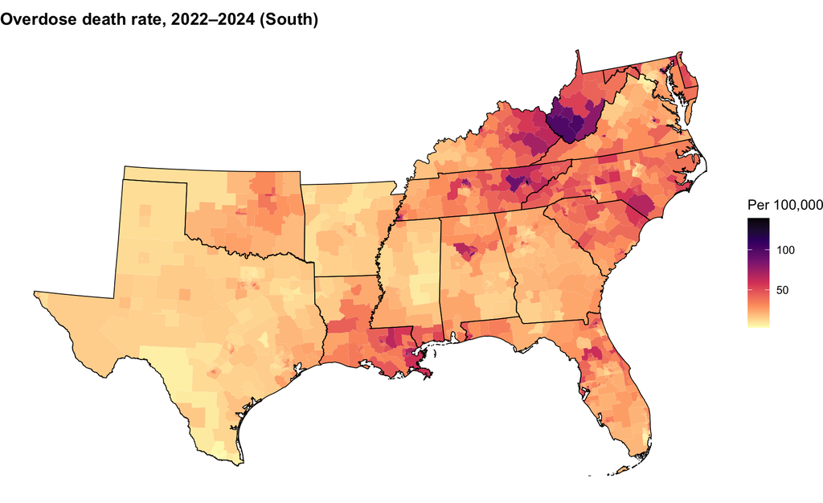

```r
ggplot(south_geo) +
  geom_sf(aes(fill = overdose_rate_2022_2024), colour = NA) +
  scale_fill_viridis_c(name = "Per 100,000", option = "magma", direction = -1,
                       na.value = "grey85") +
  state_layer +
  labs(title = "Overdose death rate, 2022–2024 (South)") +
  map_theme
```

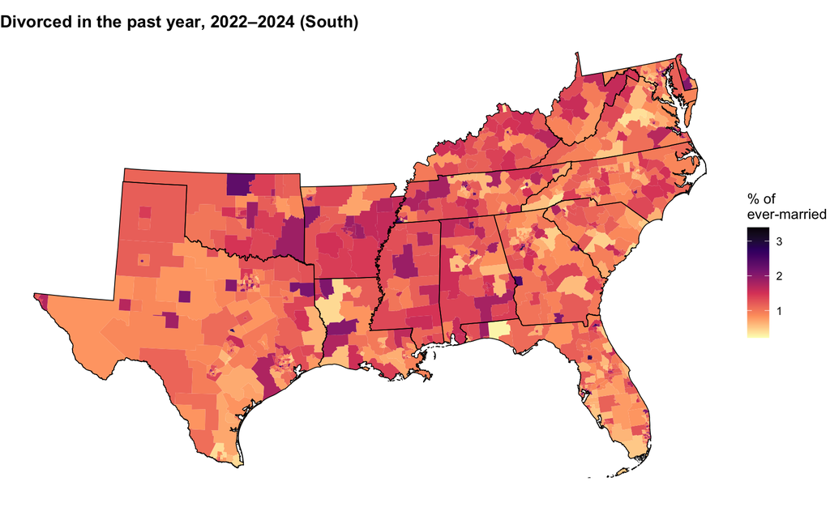

```r
ggplot(south_geo) +
  geom_sf(aes(fill = pct_divorced_past_yr), colour = NA) +
  scale_fill_viridis_c(name = "% of\never-married", option = "magma", direction = -1,
                       na.value = "grey85") +
  state_layer +
  labs(title = "Divorced in the past year, 2022–2024 (South)") +
  map_theme
```

#### 4.1.2.2 Prisons and exposure

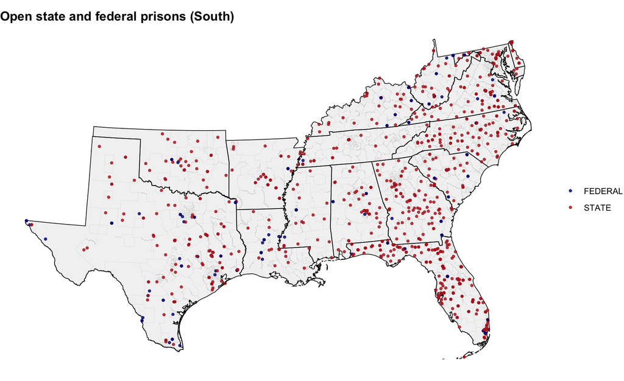

```r
# Where the prisons are (open state and federal facilities)
ggplot() +
  geom_sf(data = south_geo, fill = "grey95", colour = "grey80", linewidth = 0.05) +
  state_layer +
  geom_sf(data = south_prisons, aes(colour = TYPE), size = 0.9, alpha = 0.8) +
  scale_colour_manual(values = c(STATE = "firebrick", FEDERAL = "navy"), name = NULL) +
  labs(title = "Open state and federal prisons (South)") +
  map_theme
```

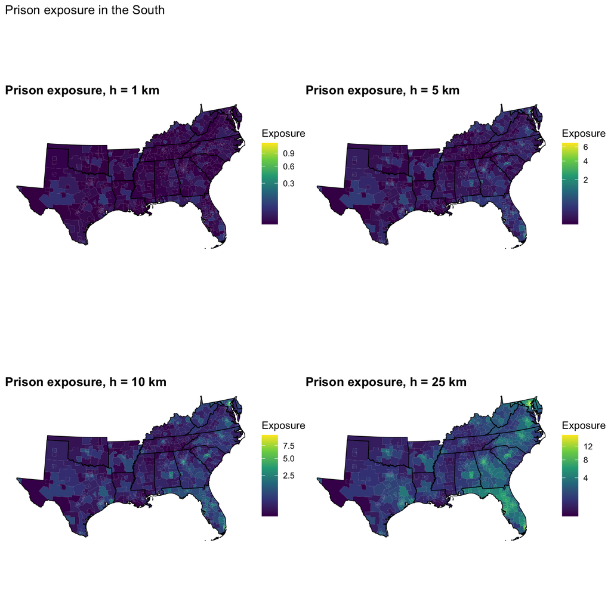

```r
exp_h1 <- ggplot(south_geo) +
  geom_sf(aes(fill = prison_exp_h1), colour = NA) +
  scale_fill_viridis_c(name = "Exposure", option = "viridis", trans = "sqrt",
                       na.value = "grey85") +
  state_layer +
  labs(title = "Prison exposure, h = 1 km") +
  map_theme

exp_h5 <- ggplot(south_geo) +
  geom_sf(aes(fill = prison_exp_h5), colour = NA) +
  scale_fill_viridis_c(name = "Exposure", option = "viridis", trans = "sqrt",
                       na.value = "grey85") +
  state_layer +
  labs(title = "Prison exposure, h = 5 km") +
  map_theme

exp_h10 <- ggplot(south_geo) +
  geom_sf(aes(fill = prison_exp_h10), colour = NA) +
  scale_fill_viridis_c(name = "Exposure", option = "viridis", trans = "sqrt",
                       na.value = "grey85") +
  state_layer +
  labs(title = "Prison exposure, h = 10 km") +
  map_theme

exp_h25 <- ggplot(south_geo) +
  geom_sf(aes(fill = prison_exp_h25), colour = NA) +
  scale_fill_viridis_c(name = "Exposure", option = "viridis", trans = "sqrt",
                       na.value = "grey85") +
  state_layer +
  labs(title = "Prison exposure, h = 25 km") +
  map_theme

(exp_h1 + exp_h5) / (exp_h10 + exp_h25) +   # 2 x 2 grid
  plot_annotation(title = "Prison exposure in the South")
```

#### 4.1.2.3 Settlement geography

These are the variables that go into M2 (the model specification, which includes area/population characteristics).

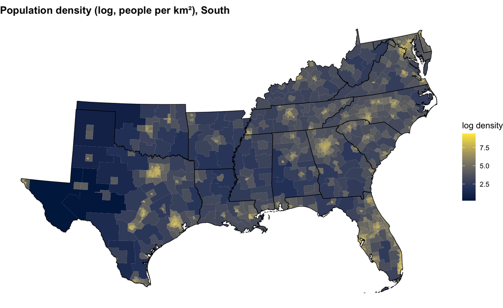

```r
ggplot(south_geo) +
  geom_sf(aes(fill = log_pop_density), colour = NA) +
  scale_fill_viridis_c(name = "log density", option = "cividis", na.value = "grey85") +
  state_layer +
  labs(title = "Population density (log, people per km²), South") +
  map_theme
```

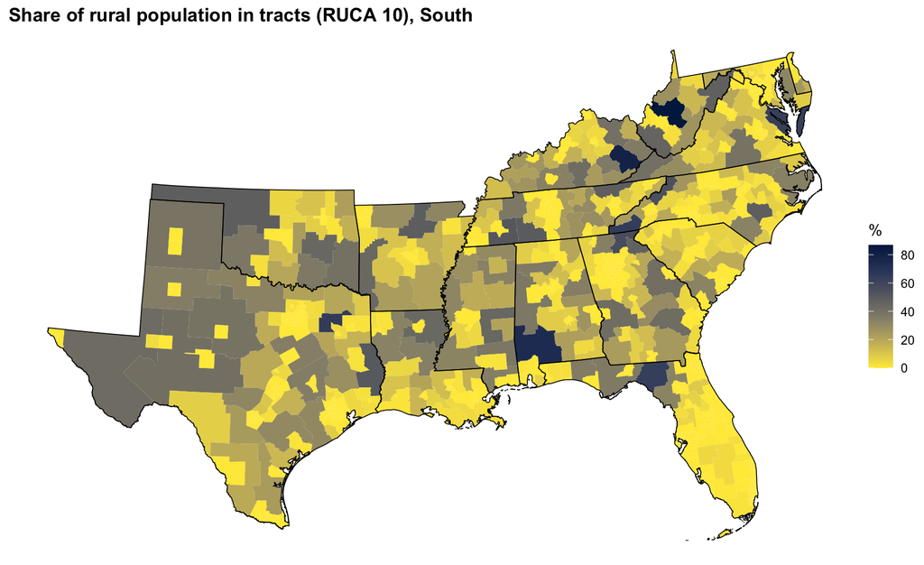

```r
ggplot(south_geo) +
  geom_sf(aes(fill = pct_pop_rural), colour = NA) +
  scale_fill_viridis_c(name = "%", option = "cividis", direction = -1, na.value = "grey85") +
  state_layer +
  labs(title = "Share of rural population in tracts (RUCA 10), South") +
  map_theme
```

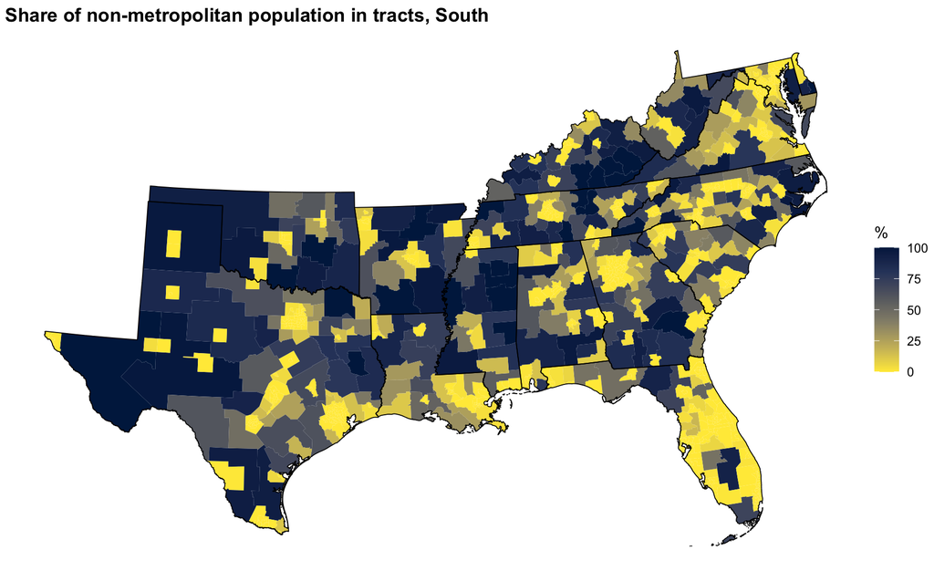

```r
ggplot(south_geo) +
  geom_sf(aes(fill = pct_pop_nonmetro), colour = NA) +
  scale_fill_viridis_c(name = "%", option = "cividis", direction = -1, na.value = "grey85") +
  state_layer +
  labs(title = "Share of non-metropolitan population in tracts, South") +
  map_theme
```

#### 4.1.2.4 Which PUMAs are selected as rural and as non-metro

A PUMA is selected when more than half of its population lives in that type of tract.

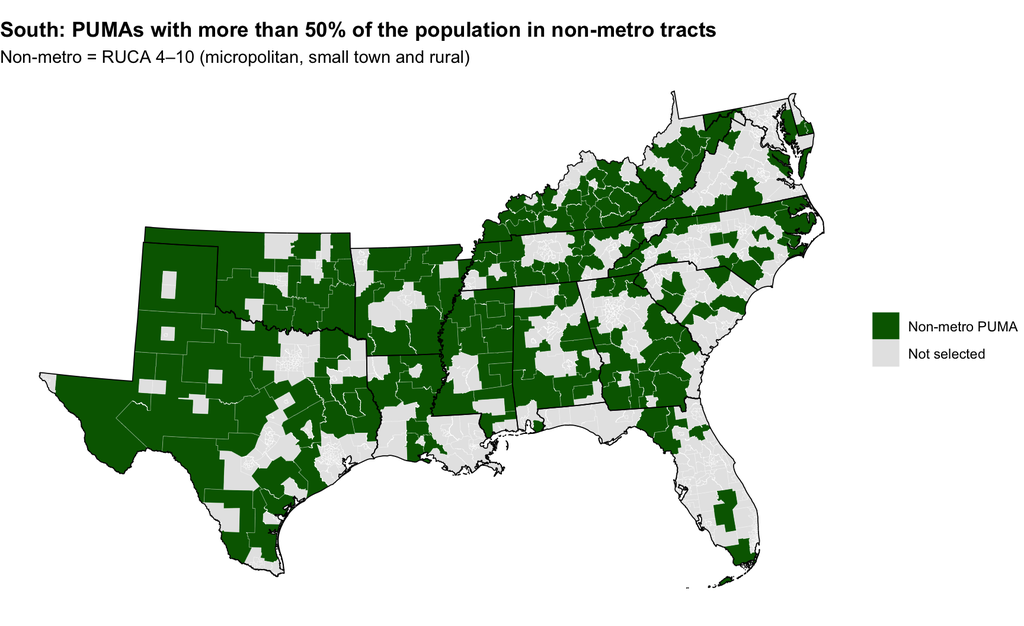

```r
south_geo %>%
  mutate(selected = if_else(pct_pop_nonmetro > 50, "Non-metro PUMA", "Not selected")) %>%
  ggplot() +
  geom_sf(aes(fill = selected), colour = "white", linewidth = 0.05) +
  scale_fill_manual(values = c("Non-metro PUMA" = "darkgreen", "Not selected" = "grey90"),
                    name = NULL, na.value = "grey85") +
  state_layer +
  labs(title = "South: PUMAs with more than 50% of the population in non-metro tracts",
       subtitle = "Non-metro = RUCA 4–10 (micropolitan, small town and rural)") +
  map_theme
```

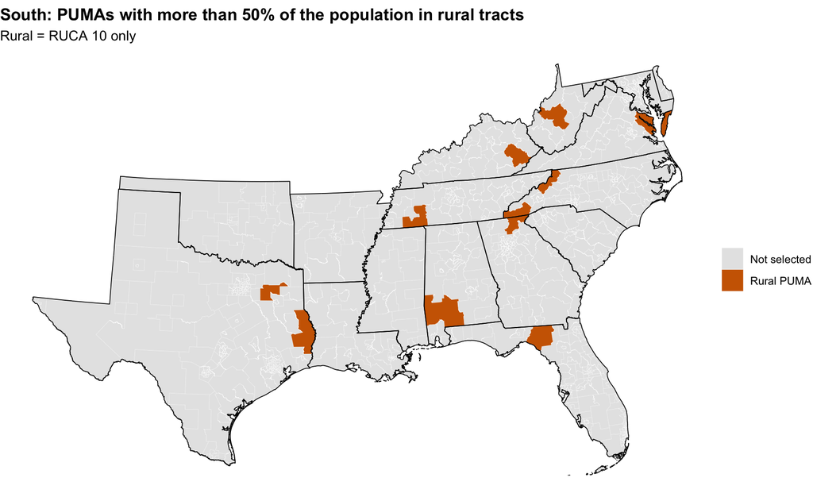

```r
south_geo %>%
  mutate(selected = if_else(pct_pop_rural > 50, "Rural PUMA", "Not selected")) %>%
  ggplot() +
  geom_sf(aes(fill = selected), colour = "white", linewidth = 0.05) +
  scale_fill_manual(values = c("Rural PUMA" = "darkorange3", "Not selected" = "grey90"),
                    name = NULL, na.value = "grey85") +
  state_layer +
  labs(title = "South: PUMAs with more than 50% of the population in rural tracts",
       subtitle = "Rural = RUCA 10 only") +
  map_theme
```

### 4.1.3 Correlations

Spearman correlations, since most of the exposure measures are very skewed.

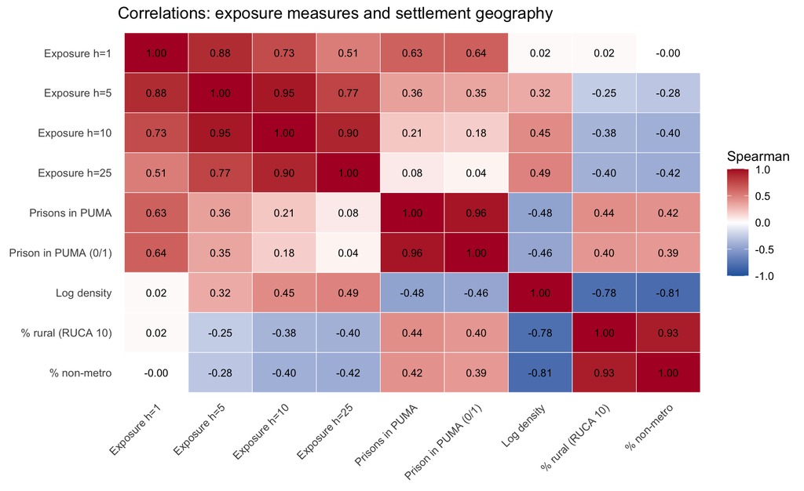

```r
cor_vars <- c(
  # Tract-based measures
  "Exposure h=1"             = "prison_exp_h1",
  "Exposure h=5"             = "prison_exp_h5",
  "Exposure h=10"             = "prison_exp_h10",
  "Exposure h=25"            = "prison_exp_h25",
  "Prisons in PUMA"           = "num_prisons_in_puma",
  "Prison in PUMA (0/1)"      = "prison_present_in_puma",
  # Settlement geography
  "Log density"               = "log_pop_density",
  "% rural (RUCA 10)"         = "pct_pop_rural",
  "% non-metro"               = "pct_pop_nonmetro"
)
cor_vars <- cor_vars[cor_vars %in% names(south_puma_df)]

cor_mat <- south_puma_df %>%
  select(all_of(cor_vars)) %>%
  cor(use = "pairwise.complete.obs", method = "spearman")

# correlation matrix code
cor_long <- as_tibble(cor_mat, rownames = "var1") %>%
  pivot_longer(-var1, names_to = "var2", values_to = "rho") %>%
  mutate(var1 = factor(var1, levels = names(cor_vars)),
         var2 = factor(var2, levels = rev(names(cor_vars))))

ggplot(cor_long, aes(var1, var2, fill = rho)) +
  geom_tile(colour = "white") +
  geom_text(aes(label = sprintf("%.2f", rho)), size = 3) +
  scale_fill_gradient2(low = "#2166ac", mid = "white", high = "#b2182b",
                       midpoint = 0, limits = c(-1, 1), name = "Spearman") +
  labs(x = NULL, y = NULL, title = "Correlations: exposure measures and settlement geography") +
  theme_minimal() +
  theme(axis.text.x = element_text(angle = 45, hjust = 1),
        panel.grid = element_blank())
```

### 4.1.4 Group comparisons

This section shows unadjusted comparisons of the outcomes across exposure groups. Prison presence gives two groups, and the number of prisons gives three (0, 1, 2+). Each decay measure is split into an “unexposed” group (exposure below 0.01, meaning no prison anywhere near where people live) and four equal-sized groups of the exposed PUMAs.

```r
south_puma_groups <- south_puma_df %>%
  mutate(
    # 1. Any prison inside the PUMA
    grp_presence = factor(if_else(prison_present_in_puma == 1, "Prison in PUMA", "No prison"),
                          levels = c("No prison", "Prison in PUMA")),
    # 2. Number of prisons inside the PUMA
    grp_count = cut(num_prisons_in_puma, breaks = c(-Inf, 0, 1, Inf),
                    labels = c("0", "1", "2+")),
    # 3. Distance-decay exposure: "unexposed" (< 0.01), then quartiles of the exposed PUMAs
    grp_h1  = if_else(prison_exp_h1  < 0.01, "Unexposed",
                      paste0("Q", ntile(if_else(prison_exp_h1  >= 0.01, prison_exp_h1,  NA_real_), 4))),
    grp_h5  = if_else(prison_exp_h5  < 0.01, "Unexposed",
                      paste0("Q", ntile(if_else(prison_exp_h5  >= 0.01, prison_exp_h5,  NA_real_), 4))),
    grp_h10 = if_else(prison_exp_h10 < 0.01, "Unexposed",
                      paste0("Q", ntile(if_else(prison_exp_h10 >= 0.01, prison_exp_h10, NA_real_), 4))),
    grp_h25 = if_else(prison_exp_h25 < 0.01, "Unexposed",
                      paste0("Q", ntile(if_else(prison_exp_h25 >= 0.01, prison_exp_h25, NA_real_), 4))),
    across(c(grp_h1, grp_h5, grp_h10, grp_h25),
           ~ factor(.x, levels = c("Unexposed", "Q1", "Q2", "Q3", "Q4"))),
    # For the stratified comparison
    metro = factor(if_else(pct_pop_nonmetro > 50, "Non-metro PUMAs", "Metro PUMAs"))
  )

groupings <- c(
  grp_presence = "Prison inside the PUMA",
  grp_count    = "Number of prisons inside the PUMA",
  grp_h1       = "Decay exposure, h = 1 km",
  grp_h5       = "Decay exposure, h = 5 km",
  grp_h10      = "Decay exposure, h = 10 km",
  grp_h25      = "Decay exposure, h = 25 km"
)

# How many PUMAs in each group
south_puma_groups %>% count(grp_presence)
```

```
    grp_presence   n
1      No prison 571
2 Prison in PUMA 381
```

```r
south_puma_groups %>% count(grp_count)
```

```
  grp_count   n
1         0 571
2         1 169
3        2+ 212
```

```r
south_puma_groups %>% count(grp_h1)
```

```
     grp_h1   n
1 Unexposed 723
2        Q1  58
3        Q2  57
4        Q3  57
5        Q4  57
```

```r
south_puma_groups %>% count(grp_h5)
```

```
     grp_h5   n
1 Unexposed 180
2        Q1 193
3        Q2 193
4        Q3 193
5        Q4 193
```

```r
south_puma_groups %>% count(grp_h10)
```

```
    grp_h10   n
1 Unexposed  23
2        Q1 233
3        Q2 232
4        Q3 232
5        Q4 232
```

```r
south_puma_groups %>% count(grp_h25)
```

```
  grp_h25   n
1      Q1 238
2      Q2 238
3      Q3 238
4      Q4 238
```

Mean, median and SD of each outcome in each group:

```r
# All group labels, in display order
group_levels <- c("No prison", "Prison in PUMA", "0", "1", "2+",
                  "Unexposed", "Q1", "Q2", "Q3", "Q4")

# Long format: one row per PUMA x outcome x grouping
group_long <- south_puma_groups %>%
  select(GEOID20, all_of(names(outcomes)), all_of(names(groupings))) %>%
  pivot_longer(all_of(names(outcomes)), names_to = "y", values_to = "value") %>%
  pivot_longer(all_of(names(groupings)), names_to = "g", values_to = "group",
               values_transform = as.character) %>%
  filter(!is.na(value), !is.na(group)) %>%
  mutate(group = factor(group, levels = group_levels))

group_stats <- group_long %>%
  group_by(y, g, group) %>%
  summarise(n = n(), mean = mean(value), median = median(value), sd = sd(value),
            .groups = "drop") %>%
  mutate(outcome  = outcomes[y],
         grouping = factor(groupings[g], levels = groupings))

group_stats %>%
  select(outcome, grouping, group, n, mean, median, sd) %>%
  arrange(outcome, grouping, group) %>%
  gt(groupname_col = c("outcome", "grouping")) %>%
  fmt_number(columns = c(mean, median, sd), decimals = 2) %>%
  tab_header(title = "Outcomes by prison exposure group")
```

Outcomes by prison exposure group

| group | n | mean | median | sd |
| --- | --- | --- | --- | --- |
| % of ever-married divorced in past year - Prison inside the PUMA |  |  |  |  |
| No prison | 571 | 1.13 | 1.07 | 0.45 |
| Prison in PUMA | 381 | 1.15 | 1.12 | 0.40 |
| % of ever-married divorced in past year - Number of prisons inside the PUMA |  |  |  |  |
| 0 | 571 | 1.13 | 1.07 | 0.45 |
| 1 | 169 | 1.13 | 1.14 | 0.41 |
| 2+ | 212 | 1.16 | 1.09 | 0.39 |
| % of ever-married divorced in past year - Decay exposure, h = 1 km |  |  |  |  |
| Unexposed | 723 | 1.12 | 1.08 | 0.42 |
| Q1 | 58 | 1.12 | 1.09 | 0.43 |
| Q2 | 57 | 1.12 | 1.09 | 0.38 |
| Q3 | 57 | 1.18 | 1.10 | 0.50 |
| Q4 | 57 | 1.37 | 1.28 | 0.46 |
| % of ever-married divorced in past year - Decay exposure, h = 5 km |  |  |  |  |
| Unexposed | 180 | 1.16 | 1.13 | 0.44 |
| Q1 | 193 | 1.04 | 1.00 | 0.37 |
| Q2 | 193 | 1.13 | 1.07 | 0.41 |
| Q3 | 193 | 1.12 | 1.13 | 0.39 |
| Q4 | 193 | 1.24 | 1.17 | 0.49 |
| % of ever-married divorced in past year - Decay exposure, h = 10 km |  |  |  |  |
| Unexposed | 23 | 1.29 | 1.25 | 0.37 |
| Q1 | 233 | 1.11 | 1.07 | 0.41 |
| Q2 | 232 | 1.11 | 1.05 | 0.41 |
| Q3 | 232 | 1.11 | 1.09 | 0.41 |
| Q4 | 232 | 1.21 | 1.15 | 0.48 |
| % of ever-married divorced in past year - Decay exposure, h = 25 km |  |  |  |  |
| Q1 | 238 | 1.18 | 1.15 | 0.41 |
| Q2 | 238 | 1.10 | 1.06 | 0.43 |
| Q3 | 238 | 1.14 | 1.10 | 0.41 |
| Q4 | 238 | 1.14 | 1.05 | 0.46 |
| Overdose deaths per 100,000 - Prison inside the PUMA |  |  |  |  |
| No prison | 571 | 26.70 | 21.80 | 17.79 |
| Prison in PUMA | 381 | 30.23 | 25.70 | 18.63 |
| Overdose deaths per 100,000 - Number of prisons inside the PUMA |  |  |  |  |
| 0 | 571 | 26.70 | 21.80 | 17.79 |
| 1 | 169 | 28.84 | 25.28 | 16.73 |
| 2+ | 212 | 31.34 | 25.93 | 19.98 |
| Overdose deaths per 100,000 - Decay exposure, h = 1 km |  |  |  |  |
| Unexposed | 723 | 26.64 | 22.48 | 15.85 |
| Q1 | 58 | 28.19 | 23.26 | 17.49 |
| Q2 | 57 | 31.50 | 29.69 | 15.91 |
| Q3 | 57 | 31.00 | 26.26 | 20.19 |
| Q4 | 57 | 40.43 | 28.56 | 34.80 |
| Overdose deaths per 100,000 - Decay exposure, h = 5 km |  |  |  |  |
| Unexposed | 180 | 26.16 | 23.17 | 16.38 |
| Q1 | 193 | 25.35 | 20.07 | 17.21 |
| Q2 | 193 | 27.84 | 23.79 | 15.24 |
| Q3 | 193 | 28.74 | 24.96 | 14.95 |
| Q4 | 193 | 32.33 | 25.79 | 24.67 |
| Overdose deaths per 100,000 - Decay exposure, h = 10 km |  |  |  |  |
| Unexposed | 23 | 24.97 | 18.25 | 14.99 |
| Q1 | 233 | 26.70 | 22.94 | 16.46 |
| Q2 | 232 | 28.18 | 22.56 | 18.18 |
| Q3 | 232 | 26.96 | 23.93 | 14.14 |
| Q4 | 232 | 30.92 | 24.63 | 22.96 |
| Overdose deaths per 100,000 - Decay exposure, h = 25 km |  |  |  |  |
| Q1 | 238 | 27.20 | 23.37 | 17.17 |
| Q2 | 238 | 28.99 | 25.11 | 17.62 |
| Q3 | 238 | 27.71 | 23.56 | 16.02 |
| Q4 | 238 | 28.55 | 23.17 | 21.57 |

The differences in means between groups show a similar pattern to the national dataset. However, the means, especially for overdose, seem to be higher in this case.

```r
# Two groups (prison in PUMA vs not): Welch t-test and Wilcoxon rank-sum test
tests_presence <- group_long %>%
  filter(g == "grp_presence") %>%
  group_by(y, g) %>%
  summarise(
    test_means = "Welch t-test",
    difference = diff(t.test(value ~ droplevels(group))$estimate),   # prison minus no prison
    p_means    = t.test(value ~ droplevels(group))$p.value,
    test_ranks = "Wilcoxon",
    p_ranks    = wilcox.test(value ~ droplevels(group))$p.value,
    p_trend    = NA_real_,
    .groups = "drop"
  )

# More than two ordered groups (count and all decay measures):
# ANOVA, Kruskal-Wallis and a linear trend test across the ordered groups
tests_ordered <- group_long %>%
  filter(g != "grp_presence") %>%
  group_by(y, g) %>%
  summarise(
    test_means = "ANOVA",
    difference = NA_real_,
    p_means    = anova(lm(value ~ droplevels(group)))$`Pr(>F)`[1],
    test_ranks = "Kruskal-Wallis",
    p_ranks    = kruskal.test(value ~ droplevels(group))$p.value,
    p_trend    = tidy(lm(value ~ as.integer(droplevels(group))))$p.value[2],   # groups as 1, 2, 3, ...
    .groups = "drop"
  )

test_results <- bind_rows(tests_presence, tests_ordered) %>%
  mutate(outcome  = outcomes[y],
         grouping = factor(groupings[g], levels = groupings)) %>%
  arrange(outcome, grouping) %>%
  select(outcome, grouping, test_means, difference, p_means, test_ranks, p_ranks, p_trend)

test_results %>%
  gt(groupname_col = "outcome") %>%
  fmt_number(columns = difference, decimals = 2) %>%
  fmt_number(columns = c(p_means, p_ranks, p_trend), decimals = 4) %>%
  sub_missing(missing_text = "") %>%
  cols_label(grouping = "Grouping", test_means = "Means test", difference = "Difference",
             p_means = "p (means)", test_ranks = "Rank test", p_ranks = "p (ranks)",
             p_trend = "p (linear trend)") %>%
  tab_header(title = "Do outcomes differ by prison exposure? (unadjusted)",
subtitle = "Difference = with prison minus without (two-group comparisons only)")
```

Do outcomes differ by prison exposure? (unadjusted)

Difference = with prison minus without (two-group comparisons only)

| Grouping | Means test | Difference | p (means) | Rank test | p (ranks) | p (linear trend) |
| --- | --- | --- | --- | --- | --- | --- |
| % of ever-married divorced in past year |  |  |  |  |  |  |
| Prison inside the PUMA | Welch t-test | 0.02 | 0.4174 | Wilcoxon | 0.1531 |  |
| Number of prisons inside the PUMA | ANOVA |  | 0.5819 | Kruskal-Wallis | 0.3113 | 0.3221 |
| Decay exposure, h = 1 km | ANOVA |  | 0.0010 | Kruskal-Wallis | 0.0034 | 0.0004 |
| Decay exposure, h = 5 km | ANOVA |  | 0.0002 | Kruskal-Wallis | 0.0010 | 0.0085 |
| Decay exposure, h = 10 km | ANOVA |  | 0.0142 | Kruskal-Wallis | 0.0410 | 0.0815 |
| Decay exposure, h = 25 km | ANOVA |  | 0.3048 | Kruskal-Wallis | 0.1606 | 0.4719 |
| Overdose deaths per 100,000 |  |  |  |  |  |  |
| Prison inside the PUMA | Welch t-test | 3.53 | 0.0036 | Wilcoxon | 0.0001 |  |
| Number of prisons inside the PUMA | ANOVA |  | 0.0055 | Kruskal-Wallis | 0.0004 | 0.0013 |
| Decay exposure, h = 1 km | ANOVA |  | 0.0000 | Kruskal-Wallis | 0.0054 | 0.0000 |
| Decay exposure, h = 5 km | ANOVA |  | 0.0017 | Kruskal-Wallis | 0.0017 | 0.0001 |
| Decay exposure, h = 10 km | ANOVA |  | 0.0729 | Kruskal-Wallis | 0.4221 | 0.0215 |
| Decay exposure, h = 25 km | ANOVA |  | 0.7072 | Kruskal-Wallis | 0.5115 | 0.6021 |

These tests check whether the outcomes differ across groups. For the two-group comparison (prison vs. no prison), we used a Welch t-test for the means and a Wilcoxon rank-sum test for the whole distributions. For the groupings with more than two groups, we used ANOVA and Kruskal-Wallis, plus a linear trend test across the ordered groups. These tests ignore the controls and assume that PUMAs are independent (they are not), so they are descriptive only.

#### 4.1.4.1 Within metro and non-metro PUMAs

The same prison vs. no prison comparison, separately for metro and non-metro PUMAs.

```r
# Prison vs. no prison, separately in metro and non-metro PUMAs.
# Welch t-test (means) and Wilcoxon rank-sum test (distributions), as in the main comparison.
stratified <- south_puma_groups %>%
  pivot_longer(all_of(names(outcomes)), names_to = "y", values_to = "value") %>%
  filter(!is.na(value), !is.na(grp_presence)) %>%
  group_by(y, metro) %>%
  summarise(
    n_no_prison    = sum(grp_presence == "No prison"),
    n_prison       = sum(grp_presence == "Prison in PUMA"),
    mean_no_prison = t.test(value ~ grp_presence)$estimate[[1]],
    mean_prison    = t.test(value ~ grp_presence)$estimate[[2]],
    difference     = mean_prison - mean_no_prison,              # prison minus no prison
    p_means        = t.test(value ~ grp_presence)$p.value,
    p_ranks        = wilcox.test(value ~ grp_presence)$p.value,
    .groups = "drop"
  ) %>%
  mutate(outcome = outcomes[y])

stratified %>%
  select(outcome, metro, n_no_prison, n_prison, mean_no_prison, mean_prison,
         difference, p_means, p_ranks) %>%
  arrange(outcome, metro) %>%
  gt(groupname_col = "outcome") %>%
  fmt_number(columns = c(mean_no_prison, mean_prison, difference), decimals = 2) %>%
  fmt_number(columns = c(p_means, p_ranks), decimals = 4) %>%
  cols_label(metro = "PUMAs", n_no_prison = "n (no prison)", n_prison = "n (prison)",
             mean_no_prison = "Mean (no prison)", mean_prison = "Mean (prison)",
             difference = "Difference", p_means = "p (t-test)", p_ranks = "p (Wilcoxon)") %>%
  tab_header(title = "Prison vs. no prison, within metro and non-metro PUMAs (unadjusted)")
```

Prison vs. no prison, within metro and non-metro PUMAs (unadjusted)

| PUMAs | n (no prison) | n (prison) | Mean (no prison) | Mean (prison) | Difference | p (t-test) | p (Wilcoxon) |
| --- | --- | --- | --- | --- | --- | --- | --- |
| % of ever-married divorced in past year |  |  |  |  |  |  |  |
| Metro PUMAs | 528 | 261 | 1.12 | 1.16 | 0.04 | 0.2747 | 0.1102 |
| Non-metro PUMAs | 43 | 120 | 1.18 | 1.13 | −0.05 | 0.3764 | 0.2960 |
| Overdose deaths per 100,000 |  |  |  |  |  |  |  |
| Metro PUMAs | 528 | 261 | 26.39 | 31.43 | 5.05 | 0.0005 | 0.0000 |
| Non-metro PUMAs | 43 | 120 | 30.53 | 27.61 | −2.92 | 0.3088 | 0.2626 |

Again, the pattern from the national dataset holds: rural pumas with prisons have lower means for both overdose and divorce…:(

## 4.2 Staged OLS models

Each model has one exposure measure. Controls are added in stages so we can see how much the exposure coefficient moves at each step.

| Model | Adds |
| --- | --- |
| M1 | nothing (exposure only) |
| M2 | settlement geography: log density, % non-metro, log population |
| M3a | M2 + economic: % unemployed, log median income |
| M3b | M2 + education: % bachelor’s or more |
| M3c | M2 + race: % non-White |
| M3d | M2 + all of the above |
| M3 | M3d + state fixed effects (main adjusted model) |
| M3-div | M3d + Census division fixed effects |

### 4.2.1 Setup and fitting

```r
# Model data: add division and log distance; standardize continuous exposures
south_puma_m <- south_puma_df %>%
  left_join(state_lookup, by = "state_fips") %>%
  mutate(across(all_of(setdiff(names(exposures), "prison_present_in_puma")),
                ~ (.x - mean(.x, na.rm = TRUE)) / sd(.x, na.rm = TRUE)))

# One complete-case sample per outcome, using that outcome's own full control set
# (same PUMAs in every model for that outcome)
south_model_data <- list(
  overdose_rate_2022_2024 = south_puma_m %>%
    drop_na(all_of(c("overdose_rate_2022_2024", names(exposures), ctrl_all,
                     "state_fips", "division"))),
  pct_divorced_past_yr = south_puma_m %>%
    drop_na(all_of(c("pct_divorced_past_yr", names(exposures), ctrl_all_div,
                     "state_fips", "division")))
)

map_int(south_model_data, nrow)   # PUMAs per outcome
```

```
overdose_rate_2022_2024    pct_divorced_past_yr
                    952                     952
```

```r
# Every outcome x specification (its own specs) x exposure, with its formula written out
south_all_models <- specs %>%
  expand_grid(x = names(exposures)) %>%
  mutate(
    rhs     = map2_chr(x, controls, ~ str_c(c(.x, .y), collapse = " + ")),
    formula = str_c(y, " ~ ", rhs, if_else(is.na(fe), "", str_c(" | ", fe))),
    model   = map2(formula, y, ~ feols(as.formula(.x), data = south_model_data[[.y]],
                                       cluster = ~state_fips))
  )

south_all_models %>% distinct(y, spec, formula)   # check: the divorce M3d/M3/M3-div should include the extra controls
```

```
# A tibble: 96 × 3
   y                       spec  formula
   <chr>                   <chr> <chr>
 1 overdose_rate_2022_2024 M1    overdose_rate_2022_2024 ~ prison_exp_h1
 2 overdose_rate_2022_2024 M1    overdose_rate_2022_2024 ~ prison_exp_h5
 3 overdose_rate_2022_2024 M1    overdose_rate_2022_2024 ~ prison_exp_h10
 4 overdose_rate_2022_2024 M1    overdose_rate_2022_2024 ~ prison_exp_h25
 5 overdose_rate_2022_2024 M1    overdose_rate_2022_2024 ~ num_prisons_in_puma
 6 overdose_rate_2022_2024 M1    overdose_rate_2022_2024 ~ prison_present_in_pu…
 7 overdose_rate_2022_2024 M2    overdose_rate_2022_2024 ~ prison_exp_h1 + log_…
 8 overdose_rate_2022_2024 M2    overdose_rate_2022_2024 ~ prison_exp_h5 + log_…
 9 overdose_rate_2022_2024 M2    overdose_rate_2022_2024 ~ prison_exp_h10 + log…
10 overdose_rate_2022_2024 M2    overdose_rate_2022_2024 ~ prison_exp_h25 + log…
# ℹ 86 more rows
```

```r
# Pull out the exposure coefficient from each model
results <- south_all_models %>%
  mutate(
    coef = map2(model, x, ~ tidy(.x, conf.int = TRUE) %>%
                              filter(term == .y) %>%
                              select(estimate, std.error, p.value, conf.low, conf.high)),
    r2 = map_dbl(model, ~ r2(.x, "r2")),
    n  = map_int(model, nobs)
  ) %>%
  select(y, x, spec, coef, r2, n) %>%
  unnest(coef) %>%
    mutate(spec = factor(spec, levels = specs_od$spec)) %>%
  group_by(y, x) %>%
  arrange(spec, .by_group = TRUE) %>%
  mutate(pct_change_from_M1 = 100 * (estimate - first(estimate)) / abs(first(estimate))) %>%
  ungroup() %>%
  mutate(outcome  = outcomes[y],
         exposure = factor(exposures[x], levels = exposures))
```

### 4.2.2 All stages, by exposure

Each table is one exposure measure across all model stages.

#### 4.2.2.1 Overdose deaths per 100,000

h = 1 km:

Positive association between the overdose rate and prison_exp_h1, significant under all specifications + the coefficient is higher than in the national model.

```r
south_models_od <- south_all_models %>%
  filter(y == "overdose_rate_2022_2024", x == "prison_exp_h1") %>%
  pull(model) %>%
  set_names(specs_od$spec)

etable(south_models_od, fitstat = ~ r2 + n, digits = 3)
```

```
                                        M1                      M2
Dependent Var.:    overdose_rate_2022_2024 overdose_rate_2022_2024

Constant                    28.1*** (3.20)           134.7* (46.6)
prison_exp_h1              6.11*** (0.927)         6.19*** (0.790)
log_pop_density                                     -0.913 (0.730)
pct_pop_nonmetro                                    -0.012 (0.039)
log_pop                                              -8.60. (4.08)
pct_unemployed
log_medhhinc
pct_bachelors_plus
pct_nonwhite
Fixed-Effects:     ----------------------- -----------------------
state_fips                              No                      No
division                                No                      No
__________________ _______________________ _______________________
S.E.: Clustered             by: state_fips          by: state_fips
R2                                 0.11289                 0.12476
Observations                           952                     952

                                       M3a                     M3b
Dependent Var.:    overdose_rate_2022_2024 overdose_rate_2022_2024

Constant                    299.2** (83.6)           106.4* (41.4)
prison_exp_h1               5.66*** (1.03)         6.13*** (0.888)
log_pop_density             -0.416 (0.941)            0.334 (1.10)
pct_pop_nonmetro           -0.077. (0.043)          -0.034 (0.042)
log_pop                       -2.81 (3.18)            -5.74 (3.73)
pct_unemployed                0.107 (1.09)
log_medhhinc                -21.0** (6.16)
pct_bachelors_plus                                 -0.341* (0.129)
pct_nonwhite
Fixed-Effects:     ----------------------- -----------------------
state_fips                              No                      No
division                                No                      No
__________________ _______________________ _______________________
S.E.: Clustered             by: state_fips          by: state_fips
R2                                 0.22528                 0.17983
Observations                           952                     952

```

[output cut: 26 more lines]

```
pct_pop_nonmetro           -0.089* (0.038)         -0.090* (0.036)
log_pop                       4.07. (2.12)            -1.14 (2.36)
pct_unemployed               1.81* (0.729)          2.59** (0.863)
log_medhhinc                 -18.0* (6.37)           -18.0* (6.66)
pct_bachelors_plus        -0.204** (0.067)          -0.149 (0.088)
pct_nonwhite             -0.272*** (0.066)       -0.374*** (0.056)
Fixed-Effects:     ----------------------- -----------------------
state_fips                             Yes                      No
division                                No                     Yes
__________________ _______________________ _______________________
S.E.: Clustered             by: state_fips          by: state_fips
R2                                 0.57626                 0.41259
Observations                           952                     952
---
Signif. codes: 0 '***' 0.001 '**' 0.01 '*' 0.05 '.' 0.1 ' ' 1
```

h = 5 km:

Positive association between the overdose rate and prison_exp_h5, significant under all specifications + the coefficient is higher than in the national model.

```r
south_models_od <- south_all_models %>%
  filter(y == "overdose_rate_2022_2024", x == "prison_exp_h5") %>%
  pull(model) %>%
  set_names(specs_od$spec)

etable(south_models_od, fitstat = ~ r2 + n, digits = 3)
```

```
                                        M1                      M2
Dependent Var.:    overdose_rate_2022_2024 overdose_rate_2022_2024

Constant                    28.1*** (3.16)           122.7* (49.9)
prison_exp_h5                 5.70* (2.45)            6.24* (2.28)
log_pop_density                                     -1.44. (0.758)
pct_pop_nonmetro                                    -0.009 (0.040)
log_pop                                               -7.34 (4.36)
pct_unemployed
log_medhhinc
pct_bachelors_plus
pct_nonwhite
Fixed-Effects:     ----------------------- -----------------------
state_fips                              No                      No
division                                No                      No
__________________ _______________________ _______________________
S.E.: Clustered             by: state_fips          by: state_fips
R2                                 0.09793                 0.11642
Observations                           952                     952

                                       M3a                     M3b
Dependent Var.:    overdose_rate_2022_2024 overdose_rate_2022_2024

Constant                    285.7** (90.9)            96.4* (43.8)
prison_exp_h5                 5.54* (2.61)            6.04* (2.43)
log_pop_density             -0.870 (0.951)           -0.204 (1.02)
pct_pop_nonmetro            -0.073 (0.044)          -0.031 (0.043)
log_pop                       -1.86 (3.31)            -4.69 (3.90)
pct_unemployed                0.123 (1.16)
log_medhhinc                -20.6** (6.43)
pct_bachelors_plus                                 -0.327* (0.122)
pct_nonwhite
Fixed-Effects:     ----------------------- -----------------------
state_fips                              No                      No
division                                No                      No
__________________ _______________________ _______________________
S.E.: Clustered             by: state_fips          by: state_fips
R2                                 0.21306                 0.16722
Observations                           952                     952

```

[output cut: 26 more lines]

```
pct_pop_nonmetro           -0.086. (0.042)         -0.088* (0.038)
log_pop                       4.47. (2.11)           -0.241 (2.35)
pct_unemployed               1.98* (0.806)           2.75* (0.950)
log_medhhinc                 -16.5* (6.06)           -17.5* (6.89)
pct_bachelors_plus        -0.224** (0.067)          -0.147 (0.087)
pct_nonwhite              -0.314** (0.080)       -0.410*** (0.060)
Fixed-Effects:     ----------------------- -----------------------
state_fips                             Yes                      No
division                                No                     Yes
__________________ _______________________ _______________________
S.E.: Clustered             by: state_fips          by: state_fips
R2                                 0.56947                 0.40387
Observations                           952                     952
---
Signif. codes: 0 '***' 0.001 '**' 0.01 '*' 0.05 '.' 0.1 ' ' 1
```

h = 10 km:

Positive association between the overdose rate and prison_exp_h10, NOT significant under any specification.

```r
south_models_od <- south_all_models %>%
  filter(y == "overdose_rate_2022_2024", x == "prison_exp_h10") %>%
  pull(model) %>%
  set_names(specs_od$spec)

etable(south_models_od, fitstat = ~ r2 + n, digits = 3)
```

```
                                        M1                      M2
Dependent Var.:    overdose_rate_2022_2024 overdose_rate_2022_2024

Constant                    28.1*** (3.20)           130.4* (48.6)
prison_exp_h10                 4.01 (3.07)             4.64 (3.15)
log_pop_density                                      -1.27 (0.763)
pct_pop_nonmetro                                    -0.002 (0.040)
log_pop                                              -8.08. (4.18)
pct_unemployed
log_medhhinc
pct_bachelors_plus
pct_nonwhite
Fixed-Effects:     ----------------------- -----------------------
state_fips                              No                      No
division                                No                      No
__________________ _______________________ _______________________
S.E.: Clustered             by: state_fips          by: state_fips
R2                                 0.04846                 0.06634
Observations                           952                     952

                                       M3a                     M3b
Dependent Var.:    overdose_rate_2022_2024 overdose_rate_2022_2024

Constant                    301.6** (93.9)           102.7* (43.0)
prison_exp_h10                 4.23 (3.45)             4.51 (3.34)
log_pop_density             -0.725 (0.998)           -0.007 (1.11)
pct_pop_nonmetro            -0.071 (0.044)          -0.024 (0.042)
log_pop                       -2.08 (3.30)            -5.29 (3.75)
pct_unemployed                0.139 (1.20)
log_medhhinc                -21.8** (6.48)
pct_bachelors_plus                                 -0.339* (0.129)
pct_nonwhite
Fixed-Effects:     ----------------------- -----------------------
state_fips                              No                      No
division                                No                      No
__________________ _______________________ _______________________
S.E.: Clustered             by: state_fips          by: state_fips
R2                                 0.17664                 0.12083
Observations                           952                     952

```

[output cut: 26 more lines]

```
pct_pop_nonmetro           -0.089. (0.042)         -0.087* (0.038)
log_pop                       4.60. (2.20)           -0.368 (2.47)
pct_unemployed               1.99* (0.808)           2.80* (0.985)
log_medhhinc                -19.0** (6.28)          -19.6** (6.51)
pct_bachelors_plus        -0.202** (0.062)          -0.120 (0.080)
pct_nonwhite              -0.322** (0.081)       -0.415*** (0.066)
Fixed-Effects:     ----------------------- -----------------------
state_fips                             Yes                      No
division                                No                     Yes
__________________ _______________________ _______________________
S.E.: Clustered             by: state_fips          by: state_fips
R2                                 0.54357                 0.37001
Observations                           952                     952
---
Signif. codes: 0 '***' 0.001 '**' 0.01 '*' 0.05 '.' 0.1 ' ' 1
```

h = 25 km:

Positive association between the overdose rate and prison_exp_h25, NOT significant under any specification.

```r
south_models_od <- south_all_models %>%
  filter(y == "overdose_rate_2022_2024", x == "prison_exp_h25") %>%
  pull(model) %>%
  set_names(specs_od$spec)

etable(south_models_od, fitstat = ~ r2 + n, digits = 3)
```

```
                                        M1                      M2
Dependent Var.:    overdose_rate_2022_2024 overdose_rate_2022_2024

Constant                    28.1*** (3.25)          151.0** (48.6)
prison_exp_h25                 1.82 (2.89)             2.21 (3.29)
log_pop_density                                     -0.719 (0.919)
pct_pop_nonmetro                                     0.003 (0.040)
log_pop                                              -10.1* (4.14)
pct_unemployed
log_medhhinc
pct_bachelors_plus
pct_nonwhite
Fixed-Effects:     ----------------------- -----------------------
state_fips                              No                      No
division                                No                      No
__________________ _______________________ _______________________
S.E.: Clustered             by: state_fips          by: state_fips
R2                                 0.01002                 0.02478
Observations                           952                     952

                                       M3a                     M3b
Dependent Var.:    overdose_rate_2022_2024 overdose_rate_2022_2024

Constant                    334.6** (95.8)           120.5* (43.6)
prison_exp_h25                 2.87 (3.66)             2.43 (3.54)
log_pop_density              -0.412 (1.10)            0.510 (1.37)
pct_pop_nonmetro           -0.072. (0.041)          -0.020 (0.041)
log_pop                       -3.13 (3.42)           -6.99. (3.76)
pct_unemployed                0.048 (1.21)
log_medhhinc                -23.8** (6.36)
pct_bachelors_plus                                 -0.356* (0.133)
pct_nonwhite
Fixed-Effects:     ----------------------- -----------------------
state_fips                              No                      No
division                                No                      No
__________________ _______________________ _______________________
S.E.: Clustered             by: state_fips          by: state_fips
R2                                 0.15176                 0.08469
Observations                           952                     952

```

[output cut: 26 more lines]

```
pct_pop_nonmetro           -0.094* (0.039)         -0.088* (0.036)
log_pop                       3.96. (2.25)            -1.60 (2.51)
pct_unemployed               1.77* (0.739)           2.66* (0.927)
log_medhhinc                -22.8** (7.68)          -22.3** (6.46)
pct_bachelors_plus         -0.159* (0.056)          -0.091 (0.069)
pct_nonwhite              -0.294** (0.076)       -0.389*** (0.070)
Fixed-Effects:     ----------------------- -----------------------
state_fips                             Yes                      No
division                                No                     Yes
__________________ _______________________ _______________________
S.E.: Clustered             by: state_fips          by: state_fips
R2                                 0.51995                 0.33963
Observations                           952                     952
---
Signif. codes: 0 '***' 0.001 '**' 0.01 '*' 0.05 '.' 0.1 ' ' 1
```

Number of prisons in the PUMA:

Positive association between the overdose rate and num_prisons_in_puma, NOT significant under any specification.

```r
south_models_od <- south_all_models %>%
  filter(y == "overdose_rate_2022_2024", x == "num_prisons_in_puma") %>%
  pull(model) %>%
  set_names(specs_od$spec)

etable(south_models_od, fitstat = ~ r2 + n, digits = 3)
```

```
                                         M1                      M2
Dependent Var.:     overdose_rate_2022_2024 overdose_rate_2022_2024

Constant                     28.1*** (3.32)          162.2** (49.9)
num_prisons_in_puma            1.34 (0.952)             1.71 (1.21)
log_pop_density                                        0.209 (1.03)
pct_pop_nonmetro                                     -0.003 (0.040)
log_pop                                               -11.5* (4.44)
pct_unemployed
log_medhhinc
pct_bachelors_plus
pct_nonwhite
Fixed-Effects:      ----------------------- -----------------------
state_fips                               No                      No
division                                 No                      No
___________________ _______________________ _______________________
S.E.: Clustered              by: state_fips          by: state_fips
R2                                  0.00541                 0.02072
Observations                            952                     952

                                        M3a                     M3b
Dependent Var.:     overdose_rate_2022_2024 overdose_rate_2022_2024

Constant                     331.3** (87.4)           132.8* (46.8)
num_prisons_in_puma            0.828 (1.22)             1.44 (1.21)
log_pop_density                0.496 (1.22)             1.40 (1.43)
pct_pop_nonmetro             -0.070 (0.042)          -0.024 (0.041)
log_pop                        -4.78 (4.00)           -8.48. (4.26)
pct_unemployed                 0.174 (1.12)
log_medhhinc                 -22.2** (6.35)
pct_bachelors_plus                                  -0.342* (0.137)
pct_nonwhite
Fixed-Effects:      ----------------------- -----------------------
state_fips                               No                      No
division                                 No                      No
___________________ _______________________ _______________________
S.E.: Clustered              by: state_fips          by: state_fips
R2                                  0.13465                 0.07615
Observations                            952                     952

```

[output cut: 26 more lines]

```
pct_pop_nonmetro            -0.096* (0.038)         -0.086* (0.037)
log_pop                         2.96 (2.37)            -2.93 (3.35)
pct_unemployed                1.73* (0.689)          2.68** (0.903)
log_medhhinc                  -22.1* (8.16)          -21.0** (6.22)
pct_bachelors_plus          -0.157* (0.062)          -0.100 (0.072)
pct_nonwhite              -0.269*** (0.059)       -0.365*** (0.058)
Fixed-Effects:      ----------------------- -----------------------
state_fips                              Yes                      No
division                                 No                     Yes
___________________ _______________________ _______________________
S.E.: Clustered              by: state_fips          by: state_fips
R2                                  0.51801                 0.33326
Observations                            952                     952
---
Signif. codes: 0 '***' 0.001 '**' 0.01 '*' 0.05 '.' 0.1 ' ' 1
```

Any prison in the PUMA:

```r
south_models_od <- south_all_models %>%
  filter(y == "overdose_rate_2022_2024", x == "prison_present_in_puma") %>%
  pull(model) %>%
  set_names(specs_od$spec)

etable(south_models_od, fitstat = ~ r2 + n, digits = 3)
```

```
                                            M1                      M2
Dependent Var.:        overdose_rate_2022_2024 overdose_rate_2022_2024

Constant                        26.7*** (3.62)          155.6** (48.6)
prison_present_in_puma             3.53 (2.11)            4.54. (2.37)
log_pop_density                                           0.468 (1.04)
pct_pop_nonmetro                                         0.002 (0.041)
log_pop                                                  -11.2* (4.31)
pct_unemployed
log_medhhinc
pct_bachelors_plus
pct_nonwhite
Fixed-Effects:         ----------------------- -----------------------
state_fips                                  No                      No
division                                    No                      No
______________________ _______________________ _______________________
S.E.: Clustered                 by: state_fips          by: state_fips
R2                                     0.00904                 0.02516
Observations                               952                     952

                                           M3a                     M3b
Dependent Var.:        overdose_rate_2022_2024 overdose_rate_2022_2024

Constant                        325.4** (91.3)           128.0* (45.2)
prison_present_in_puma             1.63 (2.51)             3.46 (2.43)
log_pop_density                   0.540 (1.17)             1.55 (1.39)
pct_pop_nonmetro                -0.067 (0.044)          -0.020 (0.042)
log_pop                           -4.66 (3.83)           -8.29. (4.11)
pct_unemployed                    0.212 (1.13)
log_medhhinc                    -21.9** (6.75)
pct_bachelors_plus                                     -0.335* (0.139)
pct_nonwhite
Fixed-Effects:         ----------------------- -----------------------
state_fips                                  No                      No
division                                    No                      No
______________________ _______________________ _______________________
S.E.: Clustered                 by: state_fips          by: state_fips
R2                                     0.13442                 0.07770
Observations                               952                     952

```

[output cut: 26 more lines]

```
pct_pop_nonmetro               -0.092* (0.038)         -0.083* (0.037)
log_pop                            3.29 (2.42)            -2.74 (3.28)
pct_unemployed                   1.78* (0.700)          2.71** (0.908)
log_medhhinc                     -22.6* (8.50)          -21.1** (6.48)
pct_bachelors_plus             -0.143* (0.065)          -0.096 (0.070)
pct_nonwhite                 -0.266*** (0.061)       -0.364*** (0.058)
Fixed-Effects:         ----------------------- -----------------------
state_fips                                 Yes                      No
division                                    No                     Yes
______________________ _______________________ _______________________
S.E.: Clustered                 by: state_fips          by: state_fips
R2                                     0.51560                 0.33202
Observations                               952                     952
---
Signif. codes: 0 '***' 0.001 '**' 0.01 '*' 0.05 '.' 0.1 ' ' 1
```

#### 4.2.2.2 % of ever-married divorced in the past year

From M3d on, the divorce models also control for religious adherence (`pct_religious`).

h = 1 km:

Positive association between the divorce rate and prison_exp_h1, significant under all specifications.

```r
south_models_div <- south_all_models %>%
  filter(y == "pct_divorced_past_yr", x == "prison_exp_h1") %>%
  pull(model) %>%
  set_names(specs_div$spec)

etable(south_models_div, fitstat = ~ r2 + n, digits = 3)
```

```
                                     M1                   M2
Dependent Var.:    pct_divorced_past_yr pct_divorced_past_yr

Constant                1.14*** (0.025)         1.40 (0.972)
prison_exp_h1          0.052*** (0.010)     0.046*** (0.009)
log_pop_density                               0.032. (0.018)
pct_pop_nonmetro                             0.002. (0.0008)
log_pop                                       -0.039 (0.080)
pct_unemployed
log_medhhinc
pct_bachelors_plus
pct_nonwhite
pct_religious
Fixed-Effects:     -------------------- --------------------
state_fips                           No                   No
division                             No                   No
__________________ ____________________ ____________________
S.E.: Clustered          by: state_fips       by: state_fips
R2                              0.01488              0.02331
Observations                        952                  952

                                    M3a                  M3b
Dependent Var.:    pct_divorced_past_yr pct_divorced_past_yr

Constant                   4.04* (1.59)        0.708 (0.893)
prison_exp_h1          0.033*** (0.007)     0.044*** (0.007)
log_pop_density         0.039** (0.013)      0.062** (0.016)
pct_pop_nonmetro        0.0002 (0.0008)      0.0010 (0.0008)
log_pop                   0.097 (0.084)        0.031 (0.073)
pct_unemployed           0.029. (0.015)
log_medhhinc          -0.392*** (0.087)
pct_bachelors_plus                          -0.008** (0.003)
pct_nonwhite
pct_religious
Fixed-Effects:     -------------------- --------------------
state_fips                           No                   No
division                             No                   No
__________________ ____________________ ____________________
S.E.: Clustered          by: state_fips       by: state_fips
R2                              0.12180              0.08272
```

[output cut: 30 more lines]

```
log_pop                  0.157. (0.081)       0.157. (0.080)
pct_unemployed           0.023. (0.013)       0.023. (0.012)
log_medhhinc          -0.352*** (0.086)     -0.312** (0.093)
pct_bachelors_plus      -0.0006 (0.002)      -0.0008 (0.003)
pct_nonwhite              0.002 (0.001)        0.002 (0.002)
pct_religious             0.001 (0.001)       0.0004 (0.001)
Fixed-Effects:     -------------------- --------------------
state_fips                          Yes                   No
division                             No                  Yes
__________________ ____________________ ____________________
S.E.: Clustered          by: state_fips       by: state_fips
R2                              0.19411              0.15433
Observations                        952                  952
---
Signif. codes: 0 '***' 0.001 '**' 0.01 '*' 0.05 '.' 0.1 ' ' 1
```

h = 5 km:

Positive association between the divorce rate and prison_exp_h5, significant under all specifications.

```r
south_models_div <- south_all_models %>%
  filter(y == "pct_divorced_past_yr", x == "prison_exp_h5") %>%
  pull(model) %>%
  set_names(specs_div$spec)

etable(south_models_div, fitstat = ~ r2 + n, digits = 3)
```

```
                                     M1                   M2
Dependent Var.:    pct_divorced_past_yr pct_divorced_past_yr

Constant                1.14*** (0.028)         1.22 (0.962)
prison_exp_h5          0.067*** (0.013)     0.063*** (0.015)
log_pop_density                                0.024 (0.019)
pct_pop_nonmetro                             0.002. (0.0008)
log_pop                                       -0.020 (0.079)
pct_unemployed
log_medhhinc
pct_bachelors_plus
pct_nonwhite
pct_religious
Fixed-Effects:     -------------------- --------------------
state_fips                           No                   No
division                             No                   No
__________________ ____________________ ____________________
S.E.: Clustered          by: state_fips       by: state_fips
R2                              0.02488              0.03097
Observations                        952                  952

                                    M3a                  M3b
Dependent Var.:    pct_divorced_past_yr pct_divorced_past_yr

Constant                   3.85* (1.57)        0.562 (0.882)
prison_exp_h5           0.046** (0.014)      0.058** (0.015)
log_pop_density          0.034* (0.013)      0.055** (0.015)
pct_pop_nonmetro        0.0002 (0.0008)      0.0010 (0.0008)
log_pop                   0.109 (0.083)        0.046 (0.072)
pct_unemployed           0.029. (0.016)
log_medhhinc          -0.385*** (0.087)
pct_bachelors_plus                          -0.008** (0.003)
pct_nonwhite
pct_religious
Fixed-Effects:     -------------------- --------------------
state_fips                           No                   No
division                             No                   No
__________________ ____________________ ____________________
S.E.: Clustered          by: state_fips       by: state_fips
R2                              0.12607              0.08825
```

[output cut: 30 more lines]

```
log_pop                  0.162* (0.076)       0.172* (0.074)
pct_unemployed           0.025. (0.013)       0.024. (0.013)
log_medhhinc           -0.325** (0.083)     -0.292** (0.092)
pct_bachelors_plus      -0.0009 (0.002)      -0.0010 (0.003)
pct_nonwhite              0.002 (0.002)        0.002 (0.002)
pct_religious             0.001 (0.001)       0.0007 (0.001)
Fixed-Effects:     -------------------- --------------------
state_fips                          Yes                   No
division                             No                  Yes
__________________ ____________________ ____________________
S.E.: Clustered          by: state_fips       by: state_fips
R2                              0.19746              0.16055
Observations                        952                  952
---
Signif. codes: 0 '***' 0.001 '**' 0.01 '*' 0.05 '.' 0.1 ' ' 1
```

h = 10 km:

Positive association between the divorce rate and prison_exp_h10, significant under all specifications.

```r
south_models_div <- south_all_models %>%
  filter(y == "pct_divorced_past_yr", x == "prison_exp_h10") %>%
  pull(model) %>%
  set_names(specs_div$spec)

etable(south_models_div, fitstat = ~ r2 + n, digits = 3)
```

```
                                     M1                   M2
Dependent Var.:    pct_divorced_past_yr pct_divorced_past_yr

Constant                1.14*** (0.029)         1.24 (0.984)
prison_exp_h10          0.059** (0.016)       0.055* (0.020)
log_pop_density                                0.024 (0.020)
pct_pop_nonmetro                             0.002. (0.0008)
log_pop                                       -0.022 (0.081)
pct_unemployed
log_medhhinc
pct_bachelors_plus
pct_nonwhite
pct_religious
Fixed-Effects:     -------------------- --------------------
state_fips                           No                   No
division                             No                   No
__________________ ____________________ ____________________
S.E.: Clustered          by: state_fips       by: state_fips
R2                              0.01930              0.02579
Observations                        952                  952

                                    M3a                  M3b
Dependent Var.:    pct_divorced_past_yr pct_divorced_past_yr

Constant                   3.92* (1.60)        0.571 (0.906)
prison_exp_h10           0.045* (0.021)       0.052* (0.021)
log_pop_density          0.032* (0.013)      0.055** (0.015)
pct_pop_nonmetro        0.0002 (0.0008)       0.001 (0.0008)
log_pop                   0.113 (0.085)        0.046 (0.074)
pct_unemployed           0.029. (0.016)
log_medhhinc          -0.394*** (0.089)
pct_bachelors_plus                          -0.008** (0.003)
pct_nonwhite
pct_religious
Fixed-Effects:     -------------------- --------------------
state_fips                           No                   No
division                             No                   No
__________________ ____________________ ____________________
S.E.: Clustered          by: state_fips       by: state_fips
R2                              0.12519              0.08442
```

[output cut: 30 more lines]

```
log_pop                  0.167* (0.075)       0.181* (0.073)
pct_unemployed           0.026. (0.013)       0.025. (0.013)
log_medhhinc          -0.331*** (0.081)     -0.303** (0.089)
pct_bachelors_plus      -0.0010 (0.002)      -0.0009 (0.003)
pct_nonwhite              0.001 (0.002)        0.001 (0.002)
pct_religious             0.001 (0.001)       0.0008 (0.001)
Fixed-Effects:     -------------------- --------------------
state_fips                          Yes                   No
division                             No                  Yes
__________________ ____________________ ____________________
S.E.: Clustered          by: state_fips       by: state_fips
R2                              0.19767              0.16112
Observations                        952                  952
---
Signif. codes: 0 '***' 0.001 '**' 0.01 '*' 0.05 '.' 0.1 ' ' 1
```

h = 25 km:

Positive association between the divorce rate and prison_exp_h25, NOT significant under any specification.

```r
south_models_div <- south_all_models %>%
  filter(y == "pct_divorced_past_yr", x == "prison_exp_h25") %>%
  pull(model) %>%
  set_names(specs_div$spec)

etable(south_models_div, fitstat = ~ r2 + n, digits = 3)
```

```
                                     M1                   M2
Dependent Var.:    pct_divorced_past_yr pct_divorced_past_yr

Constant                1.14*** (0.026)         1.53 (0.993)
prison_exp_h25            0.024 (0.020)        0.012 (0.024)
log_pop_density                               0.034. (0.019)
pct_pop_nonmetro                             0.002. (0.0008)
log_pop                                       -0.052 (0.083)
pct_unemployed
log_medhhinc
pct_bachelors_plus
pct_nonwhite
pct_religious
Fixed-Effects:     -------------------- --------------------
state_fips                           No                   No
division                             No                   No
__________________ ____________________ ____________________
S.E.: Clustered          by: state_fips       by: state_fips
R2                              0.00313              0.01279
Observations                        952                  952

                                    M3a                  M3b
Dependent Var.:    pct_divorced_past_yr pct_divorced_past_yr

Constant                   4.26* (1.65)        0.811 (0.926)
prison_exp_h25            0.023 (0.031)        0.017 (0.029)
log_pop_density          0.037* (0.014)      0.064** (0.018)
pct_pop_nonmetro        0.0002 (0.0008)       0.001 (0.0008)
log_pop                   0.098 (0.090)        0.021 (0.077)
pct_unemployed            0.029 (0.017)
log_medhhinc          -0.411*** (0.095)
pct_bachelors_plus                          -0.008** (0.003)
pct_nonwhite
pct_religious
Fixed-Effects:     -------------------- --------------------
state_fips                           No                   No
division                             No                   No
__________________ ____________________ ____________________
S.E.: Clustered          by: state_fips       by: state_fips
R2                              0.11816              0.07364
```

[output cut: 30 more lines]

```
log_pop                  0.162. (0.080)       0.172* (0.080)
pct_unemployed           0.023. (0.013)        0.023 (0.013)
log_medhhinc          -0.372*** (0.083)     -0.347** (0.091)
pct_bachelors_plus      -0.0006 (0.002)      -0.0005 (0.002)
pct_nonwhite              0.002 (0.002)        0.001 (0.002)
pct_religious             0.001 (0.001)       0.0009 (0.001)
Fixed-Effects:     -------------------- --------------------
state_fips                          Yes                   No
division                             No                  Yes
__________________ ____________________ ____________________
S.E.: Clustered          by: state_fips       by: state_fips
R2                              0.19301              0.15479
Observations                        952                  952
---
Signif. codes: 0 '***' 0.001 '**' 0.01 '*' 0.05 '.' 0.1 ' ' 1
```

Number of prisons in the PUMA:

Mostly positive association between the divorce rate and num_prisons_in_puma, NOT significant under any specification.

```r
south_models_div <- south_all_models %>%
  filter(y == "pct_divorced_past_yr", x == "num_prisons_in_puma") %>%
  pull(model) %>%
  set_names(specs_div$spec)

etable(south_models_div, fitstat = ~ r2 + n, digits = 3)
```

```
                                      M1                   M2
Dependent Var.:     pct_divorced_past_yr pct_divorced_past_yr

Constant                 1.14*** (0.024)         1.61 (0.988)
num_prisons_in_puma        0.002 (0.014)        0.014 (0.015)
log_pop_density                                0.040* (0.017)
pct_pop_nonmetro                              0.002. (0.0008)
log_pop                                        -0.061 (0.082)
pct_unemployed
log_medhhinc
pct_bachelors_plus
pct_nonwhite
pct_religious
Fixed-Effects:      -------------------- --------------------
state_fips                            No                   No
division                              No                   No
___________________ ____________________ ____________________
S.E.: Clustered           by: state_fips       by: state_fips
R2                               3.05e-5              0.01312
Observations                         952                  952

                                     M3a                  M3b
Dependent Var.:     pct_divorced_past_yr pct_divorced_past_yr

Constant                    4.21* (1.61)        0.891 (0.903)
num_prisons_in_puma       -0.007 (0.013)        0.008 (0.014)
log_pop_density          0.042** (0.014)      0.069** (0.018)
pct_pop_nonmetro         0.0003 (0.0008)       0.001 (0.0008)
log_pop                    0.091 (0.085)        0.012 (0.074)
pct_unemployed            0.030. (0.016)
log_medhhinc           -0.403*** (0.086)
pct_bachelors_plus                           -0.008** (0.003)
pct_nonwhite
pct_religious
Fixed-Effects:      -------------------- --------------------
state_fips                            No                   No
division                              No                   No
___________________ ____________________ ____________________
S.E.: Clustered           by: state_fips       by: state_fips
R2                               0.11623              0.07267
```

[output cut: 30 more lines]

```
log_pop                   0.153. (0.086)        0.144 (0.085)
pct_unemployed            0.023. (0.013)       0.023. (0.012)
log_medhhinc           -0.382*** (0.089)     -0.334** (0.093)
pct_bachelors_plus       -0.0002 (0.002)      -0.0004 (0.003)
pct_nonwhite               0.002 (0.001)        0.002 (0.001)
pct_religious              0.001 (0.001)       0.0004 (0.001)
Fixed-Effects:      -------------------- --------------------
state_fips                           Yes                   No
division                              No                  Yes
___________________ ____________________ ____________________
S.E.: Clustered           by: state_fips       by: state_fips
R2                               0.19017              0.14700
Observations                         952                  952
---
Signif. codes: 0 '***' 0.001 '**' 0.01 '*' 0.05 '.' 0.1 ' ' 1
```

Any prison in the PUMA:

Mostly positive association between the divorce rate and prison_present_in_puma, NOT significant under any specification.

```r
south_models_div <- south_all_models %>%
  filter(y == "pct_divorced_past_yr", x == "prison_present_in_puma") %>%
  pull(model) %>%
  set_names(specs_div$spec)

etable(south_models_div, fitstat = ~ r2 + n, digits = 3)
```

```
                                         M1                   M2
Dependent Var.:        pct_divorced_past_yr pct_divorced_past_yr

Constant                    1.13*** (0.027)         1.54 (0.980)
prison_present_in_puma        0.022 (0.042)        0.062 (0.045)
log_pop_density                                   0.045* (0.016)
pct_pop_nonmetro                                 0.002. (0.0008)
log_pop                                           -0.060 (0.083)
pct_unemployed
log_medhhinc
pct_bachelors_plus
pct_nonwhite
pct_religious
Fixed-Effects:         -------------------- --------------------
state_fips                               No                   No
division                                 No                   No
______________________ ____________________ ____________________
S.E.: Clustered              by: state_fips       by: state_fips
R2                                  0.00066              0.01609
Observations                            952                  952

                                        M3a                  M3b
Dependent Var.:        pct_divorced_past_yr pct_divorced_past_yr

Constant                       4.23* (1.58)        0.863 (0.905)
prison_present_in_puma       -0.003 (0.036)        0.035 (0.038)
log_pop_density             0.043** (0.013)      0.072** (0.018)
pct_pop_nonmetro            0.0002 (0.0008)       0.001 (0.0008)
log_pop                       0.088 (0.086)        0.011 (0.075)
pct_unemployed               0.030. (0.015)
log_medhhinc              -0.402*** (0.084)
pct_bachelors_plus                              -0.008** (0.003)
pct_nonwhite
pct_religious
Fixed-Effects:         -------------------- --------------------
state_fips                               No                   No
division                                 No                   No
______________________ ____________________ ____________________
S.E.: Clustered              by: state_fips       by: state_fips
R2                                  0.11601              0.07363
```

[output cut: 30 more lines]

```
log_pop                      0.154. (0.086)        0.145 (0.086)
pct_unemployed               0.023. (0.012)       0.024. (0.012)
log_medhhinc              -0.386*** (0.088)     -0.333** (0.093)
pct_bachelors_plus          -0.0001 (0.002)      -0.0004 (0.003)
pct_nonwhite                  0.002 (0.001)        0.002 (0.001)
pct_religious                 0.001 (0.001)       0.0004 (0.002)
Fixed-Effects:         -------------------- --------------------
state_fips                              Yes                   No
division                                 No                  Yes
______________________ ____________________ ____________________
S.E.: Clustered              by: state_fips       by: state_fips
R2                                  0.19015              0.14698
Observations                            952                  952
---
Signif. codes: 0 '***' 0.001 '**' 0.01 '*' 0.05 '.' 0.1 ' ' 1
```

## 4.3 Spatial models

| Model | Assumes | Role here |
| --- | --- | --- |
| SEM | nearby PUMAs share unmeasured conditions, so their errors are correlated | main spatial model |
| SDEM | SEM + exposure in neighboring PUMAs can matter too | do prisons just outside a PUMA matter? |

Both keep the full M3 specification (each outcome with its own controls). They’re estimated by maximum likelihood, so the standard errors are model-based, not clustered.

### 4.3.1 Setup

Neighbors are defined only within the South, so PUMAs on the edge of the region have fewer neighbors than in the national data. The spatial models need neighbor relations to go both ways, so the kNN weights were made symmetric: two PUMAs are neighbors if either one is among the other’s 6 nearest. Because of this, some PUMAs end up with a few morevthan six neighbors.

```r
# Southern model data with boundaries, one per outcome (same PUMAs as the South OLS models).
# Rows stay in this order for the models and the weights.
south_geo_data <- map(names(outcomes),
                      ~ puma_geo %>%
                          select(GEOID20) %>%
                          st_transform(5070) %>%
                          inner_join(south_model_data[[.x]], by = "GEOID20")) %>%
  set_names(names(outcomes))

# Neighbors within the South only
south_queen_nb <- map(south_geo_data, ~ poly2nb(.x, queen = TRUE, snap = 1))
south_knn_nb   <- map(south_geo_data, ~ .x %>%
                                          st_geometry() %>%
                                          st_point_on_surface() %>%
                                          st_coordinates() %>%
                                          knearneigh(k = 6) %>%
                                          knn2nb())

weight_labels <- c(queen = "Queen", knn = "kNN (k = 6)")

# Weights for the spatial models (kNN made symmetric for the eigen method)
south_p6_weights <- map2(south_queen_nb, south_knn_nb,
                         ~ list(queen = nb2listw(.x, style = "W", zero.policy = TRUE),
                                knn   = nb2listw(make.sym.nb(.y), style = "W")))

# Eigenvalues, computed once
south_p6_eig <- map(south_p6_weights, ~ list(queen = eigenw(similar.listw(.x$queen)),
                                             knn   = eigenw(similar.listw(.x$knn))))

# PUMAs with no queen neighbor inside the South (e.g. on the region's edge or islands)
map_int(south_queen_nb, ~ sum(card(.x) == 0))
```

```
overdose_rate_2022_2024    pct_divorced_past_yr
                      0                       0
```

```r
# South M3 formulas for each outcome and exposure, written with state dummies
# (spatial models can't use feols's "| state_fips" fixed-effects syntax)
south_spatial_models <- south_all_models %>%
  filter(spec == "M3") %>%
  transmute(y, x,
            formula_lm = str_replace(formula, " \\| state_fips", " + factor(state_fips)"))
```

### 4.3.2 SEM and SDEM, all exposure measures

```r
# Run by hand once; the models are saved and read in the next chunk
#south_spatial_models %>%
#  select(y, x, formula_lm) %>%
#  expand_grid(w = names(weight_labels)) %>%
#  mutate(
#    sem  = pmap(list(formula_lm, y, w),
#                ~ errorsarlm(as.formula(..1), data = st_drop_geometry(south_geo_data[[..2]]),
#                             listw = south_p6_weights[[..2]][[..3]], method = "eigen",
#                             control = list(pre_eig = south_p6_eig[[..2]][[..3]]),
#                             zero.policy = TRUE),
#                .progress = "South SEM"),
#    sdem = pmap(list(formula_lm, y, w, x),
#                ~ errorsarlm(as.formula(..1), data = st_drop_geometry(south_geo_data[[..2]]),
#                             listw = south_p6_weights[[..2]][[..3]],
#                             Durbin = as.formula(paste("~", ..4)),   # lag only the exposure
#                             method = "eigen",
#                             control = list(pre_eig = south_p6_eig[[..2]][[..3]]),
#                             zero.policy = TRUE),
#                .progress = "South SDEM")
#  ) %>%
#  saveRDS("data/final/south_error_models.rds")
```

```r
south_error_models <- readRDS("data/final/south_error_models.rds")
```

```r
south_error_results <- south_error_models %>%
  mutate(
    # SEM: the exposure coefficient
    sem_coef = map2(sem, x, ~ as_tibble(summary(.x)$Coef, rownames = "term") %>%
                               filter(term == .y) %>%
                               transmute(estimate = Estimate, std.error = `Std. Error`,
                                         p.value = `Pr(>|z|)`)),
    sem_lambda = map_dbl(sem, ~ .x$lambda),
    sem_aic    = map_dbl(sem, AIC),

    # SDEM direct: exposure in the PUMA itself
    sdem_direct = map2(sdem, x, ~ as_tibble(summary(.x)$Coef, rownames = "term") %>%
                                   filter(term == .y) %>%
                                   transmute(estimate = Estimate, std.error = `Std. Error`,
                                             p.value = `Pr(>|z|)`)),
    # SDEM indirect: exposure in neighboring PUMAs (the "lag." term)
    sdem_indirect = map2(sdem, x, ~ as_tibble(summary(.x)$Coef, rownames = "term") %>%
                                     filter(term == paste0("lag.", .y)) %>%
                                     transmute(estimate = Estimate, std.error = `Std. Error`,
                                               p.value = `Pr(>|z|)`)),
    # SDEM total = direct + indirect; its SE uses the covariance between the two
    sdem_total = map2(sdem, x, ~ tibble(
                   estimate  = sum(coef(.x)[c(.y, paste0("lag.", .y))]),
                   std.error = sqrt(sum(vcov(.x)[c(.y, paste0("lag.", .y)),
                                                 c(.y, paste0("lag.", .y))]))) %>%
                   mutate(p.value = 2 * pnorm(-abs(estimate / std.error)))),
    sdem_lambda = map_dbl(sdem, ~ .x$lambda),
    sdem_aic    = map_dbl(sdem, AIC)
  ) %>%
  select(-sem, -sdem)

# OLS M3 (state-clustered) from Phase 4, for comparison
ols_m3 <- results %>%
  filter(spec == "M3") %>%
  select(y, x, ols_estimate = estimate, ols_se = std.error, ols_p = p.value)
```

### 4.3.3 One exposure in detail: OLS vs. SEM vs. SDEM

Set `main_x` at the top of the chunk to choose the exposure. It is also used by the model checks below.

```r
# One comparison table: OLS M3 vs. SEM vs. SDEM for the main exposure,
# for each outcome and weights matrix

# specify the variable you want to look at
#options: prison_exp_h1, prison_exp_h5, prison_exp_h10, prison_exp_h25, num_prisons_in_puma, prison_present_in_puma
main_x <- "prison_exp_h1"

main_table <- bind_rows(
  # OLS M3 doesn't use the weights, so the same row is repeated for both weights matrices
  ols_m3 %>%
    filter(x == main_x) %>%
    expand_grid(w = names(weight_labels)) %>%
    transmute(y, w, model = "OLS M3 (state-clustered SEs)", effect = "Coefficient",
              estimate = ols_estimate, std.error = ols_se, p.value = ols_p,
              spatial_param = NA_real_, aic = NA_real_),

  # SEM: exposure coefficient, with lambda and AIC
  south_error_results %>%
    filter(x == main_x) %>%
    select(y, w, sem_coef, sem_lambda, sem_aic) %>%
    unnest(sem_coef) %>%
    transmute(y, w, model = "SEM", effect = "Coefficient",
              estimate, std.error, p.value,
              spatial_param = sem_lambda, aic = sem_aic),

  # SDEM direct: exposure in the PUMA itself (lambda and AIC shown on this row)
  south_error_results %>%
    filter(x == main_x) %>%
    select(y, w, sdem_direct, sdem_lambda, sdem_aic) %>%
    unnest(sdem_direct) %>%
    transmute(y, w, model = "SDEM", effect = "Direct",
              estimate, std.error, p.value,
              spatial_param = sdem_lambda, aic = sdem_aic),

  # SDEM indirect: exposure in neighboring PUMAs
  south_error_results %>%
    filter(x == main_x) %>%
    select(y, w, sdem_indirect) %>%
    unnest(sdem_indirect) %>%
    transmute(y, w, model = "SDEM", effect = "Indirect (neighbors)",
              estimate, std.error, p.value,
              spatial_param = NA_real_, aic = NA_real_),

  # SDEM total: direct + indirect
  south_error_results %>%
    filter(x == main_x) %>%
    select(y, w, sdem_total) %>%
    unnest(sdem_total) %>%
    transmute(y, w, model = "SDEM", effect = "Total",
              estimate, std.error, p.value,
              spatial_param = NA_real_, aic = NA_real_)
) %>%
  mutate(outcome = outcomes[y],
         weights = weight_labels[w],
         model   = factor(model, levels = c("OLS M3 (state-clustered SEs)", "SEM", "SDEM")),
         effect  = factor(effect, levels = c("Coefficient", "Direct",
                                             "Indirect (neighbors)", "Total"))) %>%
  arrange(outcome, weights, model, effect)

main_table %>%
  select(outcome, weights, model, effect, estimate, std.error, p.value, spatial_param, aic) %>%
  gt(groupname_col = c("outcome", "weights")) %>%
  fmt_number(columns = c(estimate, std.error, spatial_param), decimals = 3) %>%
  fmt_number(columns = p.value, decimals = 4) %>%
  fmt_number(columns = aic, decimals = 1) %>%
  sub_missing(missing_text = "") %>%
  cols_label(model = "Model", effect = "Effect", estimate = "β", std.error = "SE",
             p.value = "p", spatial_param = "λ", aic = "AIC") %>%
  tab_style(style = cell_fill(color = "#fff3cd"), locations = cells_body(rows = p.value < 0.05)) %>%
  tab_header(title = paste0("Main exposure (", exposures[[main_x]], ", per SD): OLS vs. spatial error models"),
             subtitle = "λ = spatial error parameter (how strongly neighboring PUMAs share unexplained variation). Shaded: p < 0.05")
```

Main exposure (Exposure, h = 1 km, per SD): OLS vs. spatial error models

λ = spatial error parameter (how strongly neighboring PUMAs share unexplained variation). Shaded: p < 0.05

| Model | Effect | β | SE | p | λ | AIC |
| --- | --- | --- | --- | --- | --- | --- |
| % of ever-married divorced in past year - Queen |  |  |  |  |  |  |
| OLS M3 (state-clustered SEs) | Coefficient | 0.029 | 0.006 | 0.0001 |  |  |
| SEM | Coefficient | 0.027 | 0.014 | 0.0467 | 0.104 | 928.9 |
| SDEM | Direct | 0.023 | 0.015 | 0.1112 | 0.100 | 930.2 |
| SDEM | Indirect (neighbors) | 0.020 | 0.025 | 0.4131 |  |  |
| SDEM | Total | 0.043 | 0.024 | 0.0695 |  |  |
| % of ever-married divorced in past year - kNN (k = 6) |  |  |  |  |  |  |
| OLS M3 (state-clustered SEs) | Coefficient | 0.029 | 0.006 | 0.0001 |  |  |
| SEM | Coefficient | 0.025 | 0.013 | 0.0606 | 0.126 | 928.6 |
| SDEM | Direct | 0.022 | 0.014 | 0.1125 | 0.119 | 925.2 |
| SDEM | Indirect (neighbors) | 0.066 | 0.028 | 0.0201 |  |  |
| SDEM | Total | 0.088 | 0.030 | 0.0034 |  |  |
| Overdose deaths per 100,000 - Queen |  |  |  |  |  |  |
| OLS M3 (state-clustered SEs) | Coefficient | 4.870 | 0.820 | 0.0000 |  |  |
| SEM | Coefficient | 2.934 | 0.356 | 0.0000 | 0.741 | 7,130.6 |
| SDEM | Direct | 3.664 | 0.365 | 0.0000 | 0.736 | 7,090.4 |
| SDEM | Indirect (neighbors) | 5.487 | 0.835 | 0.0000 |  |  |
| SDEM | Total | 9.151 | 1.007 | 0.0000 |  |  |
| Overdose deaths per 100,000 - kNN (k = 6) |  |  |  |  |  |  |
| OLS M3 (state-clustered SEs) | Coefficient | 4.870 | 0.820 | 0.0000 |  |  |
| SEM | Coefficient | 3.725 | 0.360 | 0.0000 | 0.679 | 7,244.0 |
| SDEM | Direct | 4.287 | 0.382 | 0.0000 | 0.673 | 7,229.5 |
| SDEM | Indirect (neighbors) | 4.262 | 1.045 | 0.0000 |  |  |
| SDEM | Total | 8.549 | 1.233 | 0.0000 |  |  |

### 4.3.4 All exposure measures: OLS vs. SEM vs. SDEM

```r
south_error_results %>%
  mutate(sem = sem_coef, direct = sdem_direct, indirect = sdem_indirect) %>%
  select(y, x, w, sem, direct, indirect, sem_lambda) %>%
  unnest_wider(sem,      names_sep = "_") %>%
  unnest_wider(direct,   names_sep = "_") %>%
  unnest_wider(indirect, names_sep = "_") %>%
  left_join(ols_m3, by = c("y", "x")) %>%
  mutate(outcome  = outcomes[y],
         exposure = factor(exposures[x], levels = exposures),
         weights  = weight_labels[w]) %>%
  arrange(outcome, weights, exposure) %>%
  select(outcome, weights, exposure,
         ols_estimate, ols_p,
         sem_estimate, sem_p.value,
         direct_estimate, direct_p.value,
         indirect_estimate, indirect_p.value,
         sem_lambda) %>%
  gt(groupname_col = c("outcome", "weights")) %>%
  fmt_number(columns = c(ols_estimate, sem_estimate, direct_estimate, indirect_estimate, sem_lambda),
             decimals = 3) %>%
  fmt_number(columns = c(ols_p, sem_p.value, direct_p.value, indirect_p.value), decimals = 4) %>%
  cols_label(exposure = "Exposure", ols_estimate = "OLS β", ols_p = "p",
             sem_estimate = "SEM β", sem_p.value = "p",
             direct_estimate = "SDEM direct", direct_p.value = "p",
             indirect_estimate = "SDEM indirect", indirect_p.value = "p",
             sem_lambda = "SEM λ") %>%
  tab_spanner(label = "OLS M3", columns = c(ols_estimate, ols_p)) %>%
  tab_spanner(label = "SEM", columns = c(sem_estimate, sem_p.value, sem_lambda)) %>%
  tab_spanner(label = "SDEM", columns = c(direct_estimate, direct_p.value,
                                          indirect_estimate, indirect_p.value)) %>%
  tab_header(title = "Exposure coefficients: OLS M3 vs. spatial error models",
             subtitle = "Continuous exposures per SD; presence = with vs. without")
```

Exposure coefficients: OLS M3 vs. spatial error models

Continuous exposures per SD; presence = with vs. without

| Exposure | OLS M3 OLS β | OLS M3 p | SEM SEM β | SEM p | SEM SEM λ | SDEM SDEM direct | SDEM p | SDEM SDEM indirect | SDEM p |
| --- | --- | --- | --- | --- | --- | --- | --- | --- | --- |
| % of ever-married divorced in past year - Queen |  |  |  |  |  |  |  |  |  |
| Exposure, h = 1 km | 0.029 | 0.0001 | 0.027 | 0.0467 | 0.104 | 0.023 | 0.1112 | 0.020 | 0.4131 |
| Exposure, h = 5 km | 0.045 | 0.0009 | 0.043 | 0.0069 | 0.095 | 0.035 | 0.1457 | 0.017 | 0.6166 |
| Exposure, h = 10 km | 0.052 | 0.0051 | 0.051 | 0.0057 | 0.096 | 0.067 | 0.0617 | −0.023 | 0.6083 |
| Exposure, h = 25 km | 0.040 | 0.1844 | 0.039 | 0.0988 | 0.105 | 0.086 | 0.1376 | −0.060 | 0.3729 |
| Number of prisons in PUMA | 0.002 | 0.8164 | 0.000 | 0.9888 | 0.112 | 0.001 | 0.9250 | 0.042 | 0.0678 |
| Prison in PUMA (0/1) | −0.002 | 0.9523 | −0.006 | 0.8464 | 0.113 | −0.003 | 0.9223 | 0.062 | 0.2697 |
| % of ever-married divorced in past year - kNN (k = 6) |  |  |  |  |  |  |  |  |  |
| Exposure, h = 1 km | 0.029 | 0.0001 | 0.025 | 0.0606 | 0.126 | 0.022 | 0.1125 | 0.066 | 0.0201 |
| Exposure, h = 5 km | 0.045 | 0.0009 | 0.043 | 0.0076 | 0.119 | 0.033 | 0.0789 | 0.028 | 0.3306 |
| Exposure, h = 10 km | 0.052 | 0.0051 | 0.051 | 0.0054 | 0.125 | 0.057 | 0.0289 | −0.011 | 0.7546 |
| Exposure, h = 25 km | 0.040 | 0.1844 | 0.041 | 0.0833 | 0.135 | 0.070 | 0.1014 | −0.041 | 0.4153 |
| Number of prisons in PUMA | 0.002 | 0.8164 | 0.000 | 0.9803 | 0.140 | 0.000 | 0.9871 | 0.043 | 0.1742 |
| Prison in PUMA (0/1) | −0.002 | 0.9523 | −0.008 | 0.8019 | 0.141 | −0.004 | 0.9020 | 0.123 | 0.0736 |
| Overdose deaths per 100,000 - Queen |  |  |  |  |  |  |  |  |  |
| Exposure, h = 1 km | 4.870 | 0.0000 | 2.934 | 0.0000 | 0.741 | 3.664 | 0.0000 | 5.487 | 0.0000 |
| Exposure, h = 5 km | 5.278 | 0.0212 | 4.888 | 0.0000 | 0.746 | 4.535 | 0.0000 | 2.686 | 0.0148 |
| Exposure, h = 10 km | 4.343 | 0.1427 | 4.930 | 0.0000 | 0.759 | 4.755 | 0.0000 | 0.598 | 0.6632 |
| Exposure, h = 25 km | 2.373 | 0.4616 | 2.931 | 0.0085 | 0.766 | 3.498 | 0.0134 | −1.224 | 0.5132 |
| Number of prisons in PUMA | 1.292 | 0.0966 | 0.373 | 0.2879 | 0.764 | 0.600 | 0.1651 | 0.733 | 0.3660 |
| Prison in PUMA (0/1) | 1.524 | 0.1612 | 0.171 | 0.8139 | 0.765 | 0.652 | 0.4574 | 1.919 | 0.3268 |
| Overdose deaths per 100,000 - kNN (k = 6) |  |  |  |  |  |  |  |  |  |
| Exposure, h = 1 km | 4.870 | 0.0000 | 3.725 | 0.0000 | 0.679 | 4.287 | 0.0000 | 4.262 | 0.0000 |
| Exposure, h = 5 km | 5.278 | 0.0212 | 5.084 | 0.0000 | 0.686 | 5.077 | 0.0000 | 0.770 | 0.4766 |
| Exposure, h = 10 km | 4.343 | 0.1427 | 4.918 | 0.0000 | 0.694 | 5.141 | 0.0000 | −1.406 | 0.2587 |
| Exposure, h = 25 km | 2.373 | 0.4616 | 3.084 | 0.0024 | 0.697 | 4.246 | 0.0004 | −3.119 | 0.0606 |
| Number of prisons in PUMA | 1.292 | 0.0966 | 0.840 | 0.0398 | 0.690 | 0.805 | 0.0688 | −0.249 | 0.8385 |
| Prison in PUMA (0/1) | 1.524 | 0.1612 | 1.039 | 0.2146 | 0.692 | 0.795 | 0.3868 | −1.749 | 0.5172 |

### 4.3.5 Model checks

Three checks for the exposure chosen in `main_x`: a Hausman test (do the OLS and SEM coefficients differ more than chance allows?), Moran’s I on the SEM and SDEM residuals (should be close to zero), and AIC for OLS M3, SEM and SDEM (lower is better).

```r
# Hausman test: do OLS and SEM coefficients differ more than chance allows?
hausman_safe <- possibly(Hausman.test, otherwise = list(statistic = NA_real_, p.value = NA_real_))

hausman <- south_error_models %>%
  filter(x == main_x) %>%
  mutate(test      = map(sem, hausman_safe),
         statistic = map_dbl(test, ~ unname(.x$statistic)),
         p.value   = map_dbl(test, ~ .x$p.value)) %>%
  transmute(outcome = outcomes[y], weights = weight_labels[w], statistic, p.value)
hausman
```

```
# A tibble: 4 × 4
  outcome                                 weights     statistic  p.value
  <chr>                                   <chr>           <dbl>    <dbl>
1 Overdose deaths per 100,000             Queen            16.1 9.13e- 1
2 Overdose deaths per 100,000             kNN (k = 6)     104.  1.24e-11
3 % of ever-married divorced in past year Queen            14.7 9.62e- 1
4 % of ever-married divorced in past year kNN (k = 6)      26.7 4.25e- 1
```

```r
# Is spatial structure left in the residuals of SEM and SDEM? (Should be close to zero)
resid_moran <- south_error_models %>%
  filter(x == main_x) %>%
  pivot_longer(c(sem, sdem), names_to = "model", values_to = "fit") %>%
  mutate(
    lw = map2(y, w, ~ south_p6_weights[[.x]][[.y]]),
    e  = map(fit, ~ as.vector(.x$y - .x$X %*% .x$coefficients)),
    u  = pmap(list(e, fit, lw), ~ ..1 - ..2$lambda * lag.listw(..3, ..1, zero.policy = TRUE)),
    moran_I = map2_dbl(u, lw, ~ unname(moran.test(.x, .y, zero.policy = TRUE)$estimate[1])),
    moran_p = map2_dbl(u, lw, ~ moran.test(.x, .y, zero.policy = TRUE)$p.value)
  ) %>%
  transmute(outcome = outcomes[y], weights = weight_labels[w],
            model = toupper(model), moran_I, moran_p)
resid_moran
```

```
# A tibble: 8 × 5
  outcome                                 weights     model  moran_I moran_p
  <chr>                                   <chr>       <chr>    <dbl>   <dbl>
1 Overdose deaths per 100,000             Queen       SEM   -0.00433   0.563
2 Overdose deaths per 100,000             Queen       SDEM  -0.00520   0.580
3 Overdose deaths per 100,000             kNN (k = 6) SEM   -0.0101    0.708
4 Overdose deaths per 100,000             kNN (k = 6) SDEM  -0.0138    0.780
5 % of ever-married divorced in past year Queen       SEM   -0.00205   0.519
6 % of ever-married divorced in past year Queen       SDEM  -0.00191   0.517
7 % of ever-married divorced in past year kNN (k = 6) SEM   -0.00281   0.542
8 % of ever-married divorced in past year kNN (k = 6) SDEM  -0.00260   0.537
```

```r
# Fit across models for the main measure (lower AIC = better).
south_error_results %>%
  filter(x == main_x) %>%
  select(y, w, sem_aic, sdem_aic) %>%
  left_join(south_spatial_models %>%
              filter(x == main_x) %>%
              mutate(ols = map2(formula_lm, y,
                                ~ lm(as.formula(.x), data = st_drop_geometry(south_geo_data[[.y]]))),
                     ols_aic = map_dbl(ols, AIC)) %>%
              select(y, ols_aic),
            by = "y") %>%
  mutate(outcome = outcomes[y], weights = weight_labels[w]) %>%
  select(outcome, weights, `OLS M3` = ols_aic, SEM = sem_aic, SDEM = sdem_aic)
```

```
# A tibble: 4 × 5
  outcome                                 weights     `OLS M3`   SEM  SDEM
  <chr>                                   <chr>          <dbl> <dbl> <dbl>
1 Overdose deaths per 100,000             Queen          7459. 7131. 7090.
2 Overdose deaths per 100,000             kNN (k = 6)    7459. 7244. 7229.
3 % of ever-married divorced in past year Queen           931.  929.  930.
4 % of ever-married divorced in past year kNN (k = 6)     931.  929.  925.
```